# Planning by Numbers Assignment 3 - CATEGORICAL DATA MODELS

Oliver Atwood & Charlie Townsley

2023-04-21

# Part A

```r
#run every session
library(tidyverse)
library(dplyr)
library(ggplot2)
library(caret)
library(MASS)
library(corrplot)
library(stargazer)
library(broom)
library(magrittr)
library(raster)
library(sp)
library(mlogit)
```

## A.1 Read the data into R. Run descriptive statistics as necessary.

```r
Dat_A <- read_csv("https://raw.githubusercontent.com/c-townsley/pbn_a3_repo/main/Data/Chester_Urban_Growth.csv")
```

```r
summary(Dat_A)
```

```
##      CHESCO        X                 Y              SLOPE
##  Min.   :1   Min.   :1586501   Min.   :152678   Min.   : 0.050
##  1st Qu.:1   1st Qu.:1602001   1st Qu.:173178   1st Qu.: 1.344
##  Median :1   Median :1610001   Median :186178   Median : 2.048
##  Mean   :1   Mean   :1610704   Mean   :185065   Mean   : 2.407
##  3rd Qu.:1   3rd Qu.:1618502   3rd Qu.:197178   3rd Qu.: 3.036
##  Max.   :1   Max.   :1638502   Max.   :214179   Max.   :12.042
##    FOURLNE300       INTERST800       REGRAIL300       RAILSTN100
##  Min.   :0.0000   Min.   :0.0000   Min.   :0.0000   Min.   :0.00000
##  1st Qu.:0.0000   1st Qu.:0.0000   1st Qu.:0.0000   1st Qu.:0.00000
##  Median :0.0000   Median :0.0000   Median :0.0000   Median :0.00000
##  Mean   :0.4971   Mean   :0.3426   Mean   :0.1193   Mean   :0.01253
##  3rd Qu.:1.0000   3rd Qu.:1.0000   3rd Qu.:0.0000   3rd Qu.:0.00000
##  Max.   :1.0000   Max.   :1.0000   Max.   :1.0000   Max.   :1.00000
##    PARKS500M          WATER100         CITBORO_10        DIST_WATER
##  Min.   :0.00000   Min.   :0.00000   Min.   :0.00000   Min.   :    0
##  1st Qu.:0.00000   1st Qu.:0.00000   1st Qu.:0.00000   1st Qu.: 1414
##  Median :0.00000   Median :0.00000   Median :0.00000   Median : 3162
##  Mean   :0.02276   Mean   :0.05733   Mean   :0.07015   Mean   : 3753
##  3rd Qu.:0.00000   3rd Qu.:0.00000   3rd Qu.:0.00000   3rd Qu.: 5701
##  Max.   :1.00000   Max.   :1.00000   Max.   :1.00000   Max.   :13730
##    DIST_RAILS      DIST_REGRA      DIST_PASSR      DIST_4LNE_
##  Min.   :    0   Min.   :    0   Min.   :    0   Min.   :    0
##  1st Qu.: 6671   1st Qu.: 6265   1st Qu.: 1000   1st Qu.: 1414
##  Median :12500   Median :12176   Median : 2236   Median : 3000
##  Mean   :13233   Mean   :12918   Mean   : 2763   Mean   : 3416
##  3rd Qu.:18201   3rd Qu.:18000   3rd Qu.: 4123   3rd Qu.: 5315
##  Max.   :40771   Max.   :40771   Max.   :11181   Max.   :11511
##    DIST_INTER      DIST_PARKS      PAL_WETLND         FARM92
##  Min.   :    0   Min.   :    0   Min.   :0.0000   Min.   :0.000000
##  1st Qu.: 5590   1st Qu.: 2500   1st Qu.:0.0000   1st Qu.:0.000000
##  Median :12530   Median : 4472   Median :0.0000   Median :0.000000
##  Mean   :15640   Mean   : 5161   Mean   :0.1052   Mean   :0.009219
##  3rd Qu.:24076   3rd Qu.: 7106   3rd Qu.:0.0000   3rd Qu.:0.000000
##  Max.   :49359   Max.   :16808   Max.   :1.0000   Max.   :1.000000
##    PASTURE92         FOREST92         URBAN01          URBAN92
##  Min.   :0.0000   Min.   :0.0000   Min.   :0.0000   Min.   :0.00000
##  1st Qu.:0.0000   1st Qu.:0.0000   1st Qu.:0.0000   1st Qu.:0.00000
##  Median :0.0000   Median :0.0000   Median :0.0000   Median :0.00000
##  Mean   :0.4994   Mean   :0.3518   Mean   :0.0677   Mean   :0.04883
##  3rd Qu.:1.0000   3rd Qu.:1.0000   3rd Qu.:0.0000   3rd Qu.:0.00000
##  Max.   :1.0000   Max.   :1.0000   Max.   :1.0000   Max.   :1.00000
##     POPDEN90        MEDINC90        MEDHSEVAL_       PCT_WHITE_
##  Min.   :    0   Min.   :     0   Min.   :     0   Min.   : 34.00
##  1st Qu.:   21   1st Qu.: 37986   1st Qu.:128000   1st Qu.: 94.00
##  Median :   61   Median : 45074   Median :150200   Median : 97.00
##  Mean   :  189   Mean   : 48876   Mean   :167526   Mean   : 94.74
##  3rd Qu.:  154   3rd Qu.: 56394   3rd Qu.:214200   3rd Qu.: 98.00
##  Max.   :13000   Max.   :103043   Max.   :384000   Max.   :100.00
##    PCT_SFHOME       PCT_POV_90       PCT_HSB_19       PCT_COLGRD
##  Min.   :  0.00   Min.   : 0.000   Min.   :  0.00   Min.   : 0.000
##  1st Qu.: 77.00   1st Qu.: 2.000   1st Qu.: 14.00   1st Qu.: 2.000
##  Median : 86.00   Median : 4.000   Median : 19.00   Median : 4.000
##  Mean   : 82.67   Mean   : 4.424   Mean   : 23.11   Mean   : 4.424
##  3rd Qu.: 93.00   3rd Qu.: 6.000   3rd Qu.: 31.00   3rd Qu.: 6.000
##  Max.   :100.00   Max.   :29.000   Max.   :100.00   Max.   :29.000
```

## A.2 Create New Variable for Urban Land Conversion

> Create a new binary (0/1) variable, [CHNG_URB] indicating those raster cells that were either farmland or pasture land or forest in 1992, and which converted to urban uses by 2001. Indicate these cells with a 1. All other cells should be coded to 0.

```r
Dat_A <- Dat_A %>%
  mutate(CHNG_URB = ifelse(FARM92 == 1 | PASTURE92 == 1 | FOREST92 == 1 & URBAN01 == 1, 1, 0))
```

## A.3 Build a binomial logit model to identify drivers of urban land conversion

> Build a best “lean & mean” binomial logit model that identifies the determinants of agricultural/pasture/forest land-to-urban land use change between 1992 and 2001 (This is the 0/1 variable created in step 2). Use whatever independent variables you think appropriate, and be sure to explain your logic and model development steps.

Test correlations with CHNG_URB

```r
print("SLOPE")
```

```
## [1] "SLOPE"
```

```r
cor(Dat_A$CHNG_URB, Dat_A$SLOPE, use="complete.obs", method="pearson")
```

```
## [1] -0.2689929
```

```r
print("FOURLNE300")
```

```
## [1] "FOURLNE300"
```

```r
cor(Dat_A$CHNG_URB, Dat_A$FOURLNE300, use="complete.obs", method="pearson")
```

```
## [1] -0.05593594
```

```r
print("INTERST800")
```

```
## [1] "INTERST800"
```

```r
cor(Dat_A$CHNG_URB, Dat_A$INTERST800, use="complete.obs", method="pearson")
```

```
## [1] -0.2075421
```

```r
print("REGRAIL300")
```

```
## [1] "REGRAIL300"
```

```r
cor(Dat_A$CHNG_URB, Dat_A$REGRAIL300, use="complete.obs", method="pearson")
```

```
## [1] -0.2117686
```

```r
print("PARKS500M")
```

```
## [1] "PARKS500M"
```

```r
cor(Dat_A$CHNG_URB, Dat_A$PARKS500M, use="complete.obs", method="pearson")
```

```
## [1] -0.07496059
```

```r
print("WATER100")
```

```
## [1] "WATER100"
```

```r
cor(Dat_A$CHNG_URB, Dat_A$WATER100, use="complete.obs", method="pearson")
```

```
## [1] -0.01852956
```

```r
print("CITBORO_10")
```

```
## [1] "CITBORO_10"
```

```r
cor(Dat_A$CHNG_URB, Dat_A$CITBORO_10, use="complete.obs", method="pearson")
```

```
## [1] -0.03061511
```

```r
print("DIST_WATER")
```

```
## [1] "DIST_WATER"
```

```r
cor(Dat_A$CHNG_URB, Dat_A$DIST_WATER, use="complete.obs", method="pearson")
```

```
## [1] -0.09334977
```

```r
print("DIST_RAILS")
```

```
## [1] "DIST_RAILS"
```

```r
cor(Dat_A$CHNG_URB, Dat_A$DIST_RAILS, use="complete.obs", method="pearson")
```

```
## [1] 0.290569
```

```r
print("DIST_REGRA")
```

```
## [1] "DIST_REGRA"
```

```r
cor(Dat_A$CHNG_URB, Dat_A$DIST_REGRA, use="complete.obs", method="pearson")
```

```
## [1] 0.2908341
```

```r
print("DIST_PASSR")
```

```
## [1] "DIST_PASSR"
```

```r
cor(Dat_A$CHNG_URB, Dat_A$DIST_PASSR, use="complete.obs", method="pearson")
```

```
## [1] 0.0765004
```

```r
print("DIST_4LNE_")
```

```
## [1] "DIST_4LNE_"
```

```r
cor(Dat_A$CHNG_URB, Dat_A$DIST_4LNE_, use="complete.obs", method="pearson")
```

```
## [1] 0.07289739
```

```r
print("DIST_INTER")
```

```
## [1] "DIST_INTER"
```

```r
cor(Dat_A$CHNG_URB, Dat_A$DIST_INTER, use="complete.obs", method="pearson")
```

```
## [1] 0.3188977
```

```r
print("DIST_PARKS")
```

```
## [1] "DIST_PARKS"
```

```r
cor(Dat_A$CHNG_URB, Dat_A$DIST_PARKS, use="complete.obs", method="pearson")
```

```
## [1] 0.2504532
```

```r
print("PAL_WETLND")
```

```
## [1] "PAL_WETLND"
```

```r
cor(Dat_A$CHNG_URB, Dat_A$PAL_WETLND, use="complete.obs", method="pearson")
```

```
## [1] -0.007407224
```

```r
print("POPDEN90")
```

```
## [1] "POPDEN90"
```

```r
cor(Dat_A$CHNG_URB, Dat_A$POPDEN90, use="complete.obs", method="pearson")
```

```
## [1] -0.07412875
```

```r
print("MEDINC90")
```

```
## [1] "MEDINC90"
```

```r
cor(Dat_A$CHNG_URB, Dat_A$MEDINC90, use="complete.obs", method="pearson")
```

```
## [1] -0.1479734
```

```r
print("MEDHSEVAL_")
```

```
## [1] "MEDHSEVAL_"
```

```r
cor(Dat_A$CHNG_URB, Dat_A$MEDHSEVAL_, use="complete.obs", method="pearson")
```

```
## [1] -0.1595283
```

```r
print("PCT_WHITE_")
```

```
## [1] "PCT_WHITE_"
```

```r
cor(Dat_A$CHNG_URB, Dat_A$PCT_WHITE_, use="complete.obs", method="pearson")
```

```
## [1] -0.08178655
```

```r
print("PCT_SFHOME")
```

```
## [1] "PCT_SFHOME"
```

```r
cor(Dat_A$CHNG_URB, Dat_A$PCT_SFHOME, use="complete.obs", method="pearson")
```

```
## [1] -0.0524793
```

```r
print("PCT_POV_90")
```

```
## [1] "PCT_POV_90"
```

```r
cor(Dat_A$CHNG_URB, Dat_A$PCT_POV_90, use="complete.obs", method="pearson")
```

```
## [1] 0.115068
```

```r
print("PCT_HSB_19")
```

```
## [1] "PCT_HSB_19"
```

```r
cor(Dat_A$CHNG_URB, Dat_A$PCT_HSB_19, use="complete.obs", method="pearson")
```

```
## [1] 0.07437706
```

```r
print("PCT_COLGRD")
```

```
## [1] "PCT_COLGRD"
```

```r
cor(Dat_A$CHNG_URB, Dat_A$PCT_COLGRD, use="complete.obs", method="pearson")
```

```
## [1] 0.115068
```

The variables in order of correlation with CHNG_URB are as follows: “DIST_INTER” 0.3188977 “DIST_REGRA” 0.2908341 “DIST_RAILS” 0.290569 “SLOPE” -0.2689929 “DIST_PARKS” 0.2504532 “REGRAIL300” -0.2117686 “INTERST800” -0.2075421 “MEDHSEVAL_” -0.1595283 “MEDINC90” -0.1479734 “PCT_POV_90” 0.115068 “PCT_COLGRD” 0.115068 “DIST_WATER” -0.09334977 “PCT_WHITE_” -0.08178655 “DIST_PASSR” 0.0765004 “PARKS500M” -0.07496059 “PCT_HSB_19” 0.07437706 “POPDEN90” -0.07412875 “DIST_4LNE_” 0.07289739 “FOURLNE300” -0.05593594 “PCT_SFHOME” -0.0524793 “CITBORO_10” -0.03061511 “WATER100” -0.01852956 “PAL_WETLND” -0.007407224

Let’s test the top 10 variables most correlated with CHNG_URB for colinearity using a cor plot.

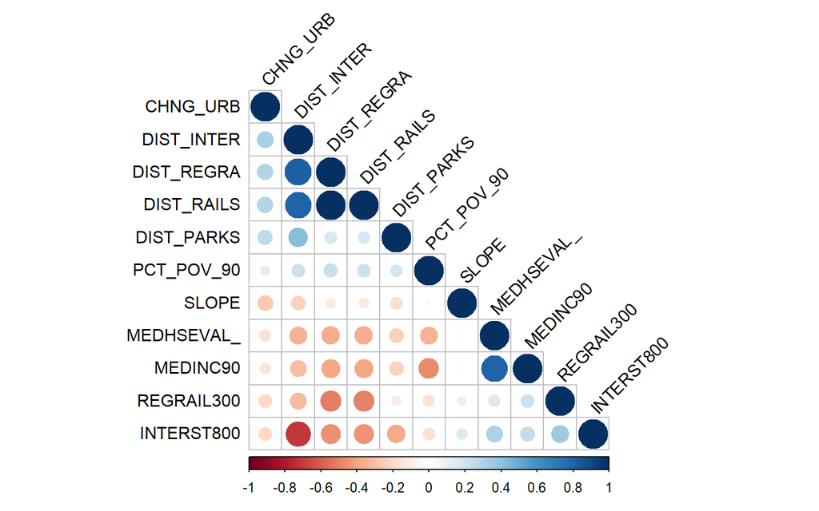

```r
#make matrix of variables we're testing
mod_vars <- Dat_A %>%
  dplyr::select(CHNG_URB, DIST_INTER, DIST_REGRA, DIST_RAILS, SLOPE, DIST_PARKS, REGRAIL300, INTERST800, MEDHSEVAL_, MEDINC90, PCT_POV_90)

#compute correlation matrix
cormatrix <- cor(mod_vars) %>%
  round(., 2)

#plot a correlogram
corrplot(cormatrix, method = "circle", type = "lower", order = "hclust",
         tl.col = "black", tl.srt = 45)
```

This plot shows that the following variables exhibit correlation with each other, meaning that their inclusion in the model is mutually exclusive.

DIST_INTER & DIST_REGRA & DIST_RAILS DIST_INTER & INTERST800 MEDHSEVAL_ & MEDINC09

```r
mod1 <- glm (CHNG_URB ~ DIST_REGRA + SLOPE + DIST_PARKS + REGRAIL300 + INTERST800 + MEDHSEVAL_ + PCT_POV_90, data=Dat_A, family = binomial)
summary(mod1)
```

```
##
## Call:
## glm(formula = CHNG_URB ~ DIST_REGRA + SLOPE + DIST_PARKS + REGRAIL300 +
##     INTERST800 + MEDHSEVAL_ + PCT_POV_90, family = binomial,
##     data = Dat_A)
##
## Deviance Residuals:
##     Min       1Q   Median       3Q      Max
## -2.2727  -1.0536   0.5299   0.9988   2.5333
##
## Coefficients:
##               Estimate Std. Error z value Pr(>|z|)
## (Intercept) -1.377e-01  1.551e-01  -0.888   0.3746
## DIST_REGRA   5.371e-05  4.197e-06  12.797  < 2e-16 ***
## SLOPE       -3.359e-01  1.958e-02 -17.152  < 2e-16 ***
## DIST_PARKS   1.153e-04  8.817e-06  13.075  < 2e-16 ***
## REGRAIL300  -5.686e-01  1.013e-01  -5.612 1.99e-08 ***
## INTERST800   9.673e-02  6.602e-02   1.465   0.1429
## MEDHSEVAL_  -1.319e-06  5.354e-07  -2.464   0.0137 *
## PCT_POV_90   1.064e-02  8.094e-03   1.315   0.1887
## ---
## Signif. codes:  0 '***' 0.001 '**' 0.01 '*' 0.05 '.' 0.1 ' ' 1
##
## (Dispersion parameter for binomial family taken to be 1)
##
##     Null deviance: 9598.7  on 6941  degrees of freedom
## Residual deviance: 8281.7  on 6934  degrees of freedom
## AIC: 8297.7
##
## Number of Fisher Scoring iterations: 4
```

PCT_POV_90 appears to be insignificant, so let’s try removing it from model 2

```r
mod2<- glm (CHNG_URB ~ DIST_REGRA + SLOPE + DIST_PARKS + REGRAIL300 + INTERST800 + MEDHSEVAL_, data=Dat_A, family = binomial)
summary(mod2)
```

```
##
## Call:
## glm(formula = CHNG_URB ~ DIST_REGRA + SLOPE + DIST_PARKS + REGRAIL300 +
##     INTERST800 + MEDHSEVAL_, family = binomial, data = Dat_A)
##
## Deviance Residuals:
##     Min       1Q   Median       3Q      Max
## -2.2759  -1.0535   0.5292   1.0023   2.5202
##
## Coefficients:
##               Estimate Std. Error z value Pr(>|z|)
## (Intercept) -6.692e-02  1.456e-01  -0.460  0.64574
## DIST_REGRA   5.403e-05  4.192e-06  12.889  < 2e-16 ***
## SLOPE       -3.357e-01  1.958e-02 -17.140  < 2e-16 ***
## DIST_PARKS   1.163e-04  8.783e-06  13.242  < 2e-16 ***
## REGRAIL300  -5.751e-01  1.011e-01  -5.686  1.3e-08 ***
## INTERST800   9.777e-02  6.599e-02   1.482  0.13845
## MEDHSEVAL_  -1.517e-06  5.143e-07  -2.948  0.00319 **
## ---
## Signif. codes:  0 '***' 0.001 '**' 0.01 '*' 0.05 '.' 0.1 ' ' 1
##
## (Dispersion parameter for binomial family taken to be 1)
##
##     Null deviance: 9598.7  on 6941  degrees of freedom
## Residual deviance: 8283.5  on 6935  degrees of freedom
## AIC: 8297.5
##
## Number of Fisher Scoring iterations: 4
```

When we remove PCT_POV_90, the AIC decreases by 0.2. INTERST800 also appears to be insignificant, so what happens if we remove that too?

```r
mod3<- glm (CHNG_URB ~ DIST_REGRA + SLOPE + DIST_PARKS + REGRAIL300 + MEDHSEVAL_, data=Dat_A, family = binomial)
summary(mod3)
```

```
##
## Call:
## glm(formula = CHNG_URB ~ DIST_REGRA + SLOPE + DIST_PARKS + REGRAIL300 +
##     MEDHSEVAL_, family = binomial, data = Dat_A)
##
## Deviance Residuals:
##     Min       1Q   Median       3Q      Max
## -2.2604  -1.0497   0.5339   1.0023   2.4842
##
## Coefficients:
##               Estimate Std. Error z value Pr(>|z|)
## (Intercept) -9.713e-03  1.403e-01  -0.069  0.94480
## DIST_REGRA   5.231e-05  4.024e-06  12.999  < 2e-16 ***
## SLOPE       -3.341e-01  1.956e-02 -17.083  < 2e-16 ***
## DIST_PARKS   1.121e-04  8.302e-06  13.507  < 2e-16 ***
## REGRAIL300  -5.511e-01  9.974e-02  -5.525  3.3e-08 ***
## MEDHSEVAL_  -1.441e-06  5.118e-07  -2.815  0.00488 **
## ---
## Signif. codes:  0 '***' 0.001 '**' 0.01 '*' 0.05 '.' 0.1 ' ' 1
##
## (Dispersion parameter for binomial family taken to be 1)
##
##     Null deviance: 9598.7  on 6941  degrees of freedom
## Residual deviance: 8285.7  on 6936  degrees of freedom
## AIC: 8297.7
##
## Number of Fisher Scoring iterations: 4
```

Since DIST_INTER is colinear with DIST_REGRA, DIST_RAILS, and INTERST800, it was not included in the first version of the model, so let’s try a model with DIST_INTER.

```r
mod4<- glm (CHNG_URB ~ DIST_INTER + SLOPE + DIST_PARKS + REGRAIL300 + MEDHSEVAL_, data=Dat_A, family = binomial)
summary(mod4)
```

```
##
## Call:
## glm(formula = CHNG_URB ~ DIST_INTER + SLOPE + DIST_PARKS + REGRAIL300 +
##     MEDHSEVAL_, family = binomial, data = Dat_A)
##
## Deviance Residuals:
##     Min       1Q   Median       3Q      Max
## -2.1208  -1.0569   0.5717   1.0036   2.4169
##
## Coefficients:
##               Estimate Std. Error z value Pr(>|z|)
## (Intercept)  4.409e-01  1.258e-01   3.505 0.000456 ***
## DIST_INTER   3.118e-05  2.678e-06  11.643  < 2e-16 ***
## SLOPE       -3.184e-01  1.985e-02 -16.039  < 2e-16 ***
## DIST_PARKS   8.135e-05  8.688e-06   9.363  < 2e-16 ***
## REGRAIL300  -8.666e-01  9.161e-02  -9.459  < 2e-16 ***
## MEDHSEVAL_  -2.109e-06  5.016e-07  -4.205 2.61e-05 ***
## ---
## Signif. codes:  0 '***' 0.001 '**' 0.01 '*' 0.05 '.' 0.1 ' ' 1
##
## (Dispersion parameter for binomial family taken to be 1)
##
##     Null deviance: 9598.7  on 6941  degrees of freedom
## Residual deviance: 8322.3  on 6936  degrees of freedom
## AIC: 8334.3
##
## Number of Fisher Scoring iterations: 4
```

The AIC increased on this model compared to the previous ones, so it seems like model 2 is the way to go.

```r
#model1
#calc the predicted probabilities based on the model
pred <- as.data.frame(fitted(mod1))
pred <- rename(pred, "prob" = "fitted(mod1)")
pred <- mutate(pred, "binary" = ifelse(prob < 0.5, 0, 1))
#append column to original data frame
Dat_A$binary <- pred$binary
head(Dat_A)
```

```
## # A tibble: 6 × 34
##   CHESCO        X       Y SLOPE FOURLNE300 INTERST800 REGRAIL300 RAILSTN100
##    <dbl>    <dbl>   <dbl> <dbl>      <dbl>      <dbl>      <dbl>      <dbl>
## 1      1 1615501. 214179. 1.16           1          0          0          0
## 2      1 1616001. 214179. 0.707          1          0          0          0
## 3      1 1610001. 213679. 0.756          1          0          0          0
## 4      1 1610501. 213679. 0.736          1          0          0          0
## 5      1 1611001. 213679. 1.60           1          0          0          0
## 6      1 1611501. 213679. 1.77           1          0          0          0
## # ℹ 26 more variables: PARKS500M <dbl>, WATER100 <dbl>, CITBORO_10 <dbl>,
## #   DIST_WATER <dbl>, DIST_RAILS <dbl>, DIST_REGRA <dbl>, DIST_PASSR <dbl>,
## #   DIST_4LNE_ <dbl>, DIST_INTER <dbl>, DIST_PARKS <dbl>, PAL_WETLND <dbl>,
## #   FARM92 <dbl>, PASTURE92 <dbl>, FOREST92 <dbl>, URBAN01 <dbl>,
## #   URBAN92 <dbl>, POPDEN90 <dbl>, MEDINC90 <dbl>, MEDHSEVAL_ <dbl>,
## #   PCT_WHITE_ <dbl>, PCT_SFHOME <dbl>, PCT_POV_90 <dbl>, PCT_HSB_19 <dbl>,
## #   PCT_COLGRD <dbl>, CHNG_URB <dbl>, binary <dbl>
```

```r
#calculate accuracy rate
mod1_Acc <- (sum(Dat_A$URBAN01 == 1 & Dat_A$binary == 1) + sum(Dat_A$URBAN01 == 0 & Dat_A$binary == 0)) / nrow(Dat_A)

#model2
#calc the predicted probabilities based on the model
pred <- as.data.frame(fitted(mod2))
pred <- rename(pred, "prob" = "fitted(mod2)")
pred <- mutate(pred, "binary" = ifelse(prob < 0.5, 0, 1))
#append column to original data frame
Dat_A$binary <- pred$binary
head(Dat_A)
```

```
## # A tibble: 6 × 34
##   CHESCO        X       Y SLOPE FOURLNE300 INTERST800 REGRAIL300 RAILSTN100
##    <dbl>    <dbl>   <dbl> <dbl>      <dbl>      <dbl>      <dbl>      <dbl>
## 1      1 1615501. 214179. 1.16           1          0          0          0
## 2      1 1616001. 214179. 0.707          1          0          0          0
## 3      1 1610001. 213679. 0.756          1          0          0          0
## 4      1 1610501. 213679. 0.736          1          0          0          0
## 5      1 1611001. 213679. 1.60           1          0          0          0
## 6      1 1611501. 213679. 1.77           1          0          0          0
## # ℹ 26 more variables: PARKS500M <dbl>, WATER100 <dbl>, CITBORO_10 <dbl>,
## #   DIST_WATER <dbl>, DIST_RAILS <dbl>, DIST_REGRA <dbl>, DIST_PASSR <dbl>,
## #   DIST_4LNE_ <dbl>, DIST_INTER <dbl>, DIST_PARKS <dbl>, PAL_WETLND <dbl>,
## #   FARM92 <dbl>, PASTURE92 <dbl>, FOREST92 <dbl>, URBAN01 <dbl>,
## #   URBAN92 <dbl>, POPDEN90 <dbl>, MEDINC90 <dbl>, MEDHSEVAL_ <dbl>,
## #   PCT_WHITE_ <dbl>, PCT_SFHOME <dbl>, PCT_POV_90 <dbl>, PCT_HSB_19 <dbl>,
## #   PCT_COLGRD <dbl>, CHNG_URB <dbl>, binary <dbl>
```

```r
#calculate accuracy rate
mod2_Acc <- (sum(Dat_A$URBAN01 == 1 & Dat_A$binary == 1) + sum(Dat_A$URBAN01 == 0 & Dat_A$binary == 0)) / nrow(Dat_A)

#model3
#calc the predicted probabilities based on the model
pred <- as.data.frame(fitted(mod3))
pred <- rename(pred, "prob" = "fitted(mod3)")
pred <- mutate(pred, "binary" = ifelse(prob < 0.5, 0, 1))
#append column to original data frame
Dat_A$binary <- pred$binary
head(Dat_A)
```

```
## # A tibble: 6 × 34
##   CHESCO        X       Y SLOPE FOURLNE300 INTERST800 REGRAIL300 RAILSTN100
##    <dbl>    <dbl>   <dbl> <dbl>      <dbl>      <dbl>      <dbl>      <dbl>
## 1      1 1615501. 214179. 1.16           1          0          0          0
## 2      1 1616001. 214179. 0.707          1          0          0          0
## 3      1 1610001. 213679. 0.756          1          0          0          0
## 4      1 1610501. 213679. 0.736          1          0          0          0
## 5      1 1611001. 213679. 1.60           1          0          0          0
## 6      1 1611501. 213679. 1.77           1          0          0          0
## # ℹ 26 more variables: PARKS500M <dbl>, WATER100 <dbl>, CITBORO_10 <dbl>,
## #   DIST_WATER <dbl>, DIST_RAILS <dbl>, DIST_REGRA <dbl>, DIST_PASSR <dbl>,
## #   DIST_4LNE_ <dbl>, DIST_INTER <dbl>, DIST_PARKS <dbl>, PAL_WETLND <dbl>,
## #   FARM92 <dbl>, PASTURE92 <dbl>, FOREST92 <dbl>, URBAN01 <dbl>,
## #   URBAN92 <dbl>, POPDEN90 <dbl>, MEDINC90 <dbl>, MEDHSEVAL_ <dbl>,
## #   PCT_WHITE_ <dbl>, PCT_SFHOME <dbl>, PCT_POV_90 <dbl>, PCT_HSB_19 <dbl>,
## #   PCT_COLGRD <dbl>, CHNG_URB <dbl>, binary <dbl>
```

```r
#calculate accuracy rate
mod3_Acc <- (sum(Dat_A$URBAN01 == 1 & Dat_A$binary == 1) + sum(Dat_A$URBAN01 == 0 & Dat_A$binary == 0)) / nrow(Dat_A)

#model4
#calc the predicted probabilities based on the model
pred <- as.data.frame(fitted(mod4))
pred <- rename(pred, "prob" = "fitted(mod4)")
pred <- mutate(pred, "binary" = ifelse(prob < 0.5, 0, 1))
#append column to original data frame
Dat_A$binary <- pred$binary
head(Dat_A)
```

```
## # A tibble: 6 × 34
##   CHESCO        X       Y SLOPE FOURLNE300 INTERST800 REGRAIL300 RAILSTN100
##    <dbl>    <dbl>   <dbl> <dbl>      <dbl>      <dbl>      <dbl>      <dbl>
## 1      1 1615501. 214179. 1.16           1          0          0          0
## 2      1 1616001. 214179. 0.707          1          0          0          0
## 3      1 1610001. 213679. 0.756          1          0          0          0
## 4      1 1610501. 213679. 0.736          1          0          0          0
## 5      1 1611001. 213679. 1.60           1          0          0          0
## 6      1 1611501. 213679. 1.77           1          0          0          0
## # ℹ 26 more variables: PARKS500M <dbl>, WATER100 <dbl>, CITBORO_10 <dbl>,
## #   DIST_WATER <dbl>, DIST_RAILS <dbl>, DIST_REGRA <dbl>, DIST_PASSR <dbl>,
## #   DIST_4LNE_ <dbl>, DIST_INTER <dbl>, DIST_PARKS <dbl>, PAL_WETLND <dbl>,
## #   FARM92 <dbl>, PASTURE92 <dbl>, FOREST92 <dbl>, URBAN01 <dbl>,
## #   URBAN92 <dbl>, POPDEN90 <dbl>, MEDINC90 <dbl>, MEDHSEVAL_ <dbl>,
## #   PCT_WHITE_ <dbl>, PCT_SFHOME <dbl>, PCT_POV_90 <dbl>, PCT_HSB_19 <dbl>,
## #   PCT_COLGRD <dbl>, CHNG_URB <dbl>, binary <dbl>
```

```r
#calculate accuracy rate
mod4_Acc <- (sum(Dat_A$URBAN01 == 1 & Dat_A$binary == 1) + sum(Dat_A$URBAN01 == 0 & Dat_A$binary == 0)) / nrow(Dat_A)

print("model 1 Accuracy")
```

```
## [1] "model 1 Accuracy"
```

```r
mod1_Acc
```

```
## [1] 0.4201959
```

```r
print("model 2 Accuracy")
```

```
## [1] "model 2 Accuracy"
```

```r
mod2_Acc
```

```
## [1] 0.4216364
```

```r
print("model 3 Accuracy")
```

```
## [1] "model 3 Accuracy"
```

```r
mod3_Acc
```

```
## [1] 0.4188995
```

```r
print("model 4 Accuracy")
```

```
## [1] "model 4 Accuracy"
```

```r
mod4_Acc
```

```
## [1] 0.4060789
```

Let’s try this another way. What happens if we let the machine do the work of sorting out which variables to include in the model?

```r
Dat_B <- Dat_A %>% dplyr::select(-CHESCO, -X, -Y, -PCT_COLGRD, -binary, -FARM92, -PASTURE92, -FOREST92, -URBAN01, -URBAN92)

set.seed(3456)
trainIndex <- createDataPartition(Dat_A$CHNG_URB, p = .70, list = FALSE, times = 1)

Dat_B_Train <- Dat_B[ trainIndex,]
Dat_B_Test  <- Dat_B[-trainIndex,]

ML_Model1 <- glm(CHNG_URB ~ ., family="binomial"(link="logit"), data = Dat_B_Train)
summary(ML_Model1)
```

```
##
## Call:
## glm(formula = CHNG_URB ~ ., family = binomial(link = "logit"),
##     data = Dat_B_Train)
##
## Deviance Residuals:
##     Min       1Q   Median       3Q      Max
## -2.2836  -1.0420   0.4719   0.9824   2.8719
##
## Coefficients:
##               Estimate Std. Error z value Pr(>|z|)
## (Intercept) -6.990e-02  7.048e-01  -0.099 0.920998
## SLOPE       -3.149e-01  2.383e-02 -13.216  < 2e-16 ***
## FOURLNE300   3.321e-01  1.181e-01   2.812 0.004919 **
## INTERST800   4.354e-01  1.095e-01   3.975 7.04e-05 ***
## REGRAIL300  -1.197e+00  1.534e-01  -7.805 5.95e-15 ***
## RAILSTN100   1.174e+00  3.135e-01   3.745 0.000180 ***
## PARKS500M   -5.987e-01  2.561e-01  -2.338 0.019401 *
## WATER100    -6.758e-01  1.529e-01  -4.419 9.90e-06 ***
## CITBORO_10  -2.293e-02  1.439e-01  -0.159 0.873420
## DIST_WATER  -5.434e-05  1.366e-05  -3.977 6.98e-05 ***
## DIST_RAILS   4.415e-04  7.747e-05   5.699 1.20e-08 ***
## DIST_REGRA  -4.063e-04  7.905e-05  -5.140 2.75e-07 ***
## DIST_PASSR  -1.892e-05  1.892e-05  -1.000 0.317209
## DIST_4LNE_   2.429e-05  2.570e-05   0.945 0.344728
## DIST_INTER   2.640e-05  7.645e-06   3.453 0.000554 ***
## DIST_PARKS   1.181e-04  1.273e-05   9.280  < 2e-16 ***
## PAL_WETLND   1.717e-01  1.035e-01   1.660 0.097008 .
## POPDEN90    -6.914e-05  6.316e-05  -1.095 0.273686
## MEDINC90    -1.641e-05  6.035e-06  -2.719 0.006551 **
## MEDHSEVAL_   7.347e-07  1.125e-06   0.653 0.513671
## PCT_WHITE_  -7.331e-03  6.502e-03  -1.128 0.259510
## PCT_SFHOME   1.138e-02  4.238e-03   2.684 0.007266 **
## PCT_POV_90   5.094e-02  1.160e-02   4.391 1.13e-05 ***
## PCT_HSB_19  -1.818e-02  3.695e-03  -4.922 8.59e-07 ***
## ---
## Signif. codes:  0 '***' 0.001 '**' 0.01 '*' 0.05 '.' 0.1 ' ' 1
##
## (Dispersion parameter for binomial family taken to be 1)
##
##     Null deviance: 6724.3  on 4859  degrees of freedom
## Residual deviance: 5677.0  on 4836  degrees of freedom
## AIC: 5725
##
## Number of Fisher Scoring iterations: 4
```

Train another model, this time removing the variables we know are colinear from our corr plot.

```r
Dat_C <- Dat_B %>% dplyr::select(-DIST_REGRA, -DIST_RAILS, -INTERST800, -MEDINC90)

set.seed(3456)
trainIndex2 <- createDataPartition(Dat_C$DIST_INTER, p = .70, list = FALSE, times = 1)

Dat_C_Train <- Dat_C[ trainIndex2,]
Dat_C_Test  <- Dat_C[-trainIndex2,]

ML_Model2 <- glm(CHNG_URB ~ ., family="binomial"(link="logit"), data = Dat_C_Train)
summary(ML_Model2)
```

```
##
## Call:
## glm(formula = CHNG_URB ~ ., family = binomial(link = "logit"),
##     data = Dat_C_Train)
##
## Deviance Residuals:
##     Min       1Q   Median       3Q      Max
## -2.2081  -1.0496   0.5268   0.9820   2.3878
##
## Coefficients:
##               Estimate Std. Error z value Pr(>|z|)
## (Intercept) -5.890e-01  6.505e-01  -0.905 0.365241
## SLOPE       -3.237e-01  2.422e-02 -13.366  < 2e-16 ***
## FOURLNE300   2.761e-01  1.165e-01   2.370 0.017765 *
## REGRAIL300  -1.217e+00  1.322e-01  -9.203  < 2e-16 ***
## RAILSTN100   9.617e-01  3.003e-01   3.203 0.001361 **
## PARKS500M   -5.592e-01  2.353e-01  -2.377 0.017459 *
## WATER100    -6.107e-01  1.462e-01  -4.177 2.95e-05 ***
## CITBORO_10  -2.009e-01  1.443e-01  -1.392 0.163911
## DIST_WATER  -3.902e-05  1.333e-05  -2.927 0.003426 **
## DIST_PASSR  -1.504e-05  1.794e-05  -0.838 0.401867
## DIST_4LNE_  -3.423e-06  2.521e-05  -0.136 0.891991
## DIST_INTER   3.079e-05  3.438e-06   8.957  < 2e-16 ***
## DIST_PARKS   8.771e-05  1.139e-05   7.698 1.39e-14 ***
## PAL_WETLND   1.236e-01  1.037e-01   1.191 0.233507
## POPDEN90    -1.071e-04  6.110e-05  -1.752 0.079784 .
## MEDHSEVAL_  -2.448e-06  7.738e-07  -3.163 0.001559 **
## PCT_WHITE_   8.633e-03  5.674e-03   1.521 0.128138
## PCT_SFHOME   4.702e-03  2.968e-03   1.584 0.113142
## PCT_POV_90   3.961e-02  1.131e-02   3.502 0.000461 ***
## PCT_HSB_19  -6.897e-03  3.089e-03  -2.233 0.025574 *
## ---
## Signif. codes:  0 '***' 0.001 '**' 0.01 '*' 0.05 '.' 0.1 ' ' 1
##
## (Dispersion parameter for binomial family taken to be 1)
##
##     Null deviance: 6723.7  on 4860  degrees of freedom
## Residual deviance: 5724.5  on 4841  degrees of freedom
## AIC: 5764.5
##
## Number of Fisher Scoring iterations: 4
```

The AIC increased on Model2 relative to Model1…

Train a third model, removing variables with poor performance indicated by high p-values, along with the intercept.

```r
Dat_D <- Dat_C %>% dplyr::select(-CITBORO_10, -DIST_PASSR, -DIST_4LNE_, -PAL_WETLND, -PCT_WHITE_, -PCT_SFHOME)

set.seed(3456)
trainIndex3 <- createDataPartition(Dat_D$DIST_INTER, p = .70, list = FALSE, times = 1)

Dat_D_Train <- Dat_D[ trainIndex3,]
Dat_D_Test  <- Dat_D[-trainIndex3,]

ML_Model3 <- glm(CHNG_URB ~ ., family="binomial"(link="logit"), data = Dat_D_Train)
summary(ML_Model3)
```

```
##
## Call:
## glm(formula = CHNG_URB ~ ., family = binomial(link = "logit"),
##     data = Dat_D_Train)
##
## Deviance Residuals:
##     Min       1Q   Median       3Q      Max
## -2.1569  -1.0464   0.5270   0.9831   2.3961
##
## Coefficients:
##               Estimate Std. Error z value Pr(>|z|)
## (Intercept)  5.594e-01  1.857e-01   3.012 0.002597 **
## SLOPE       -3.235e-01  2.410e-02 -13.425  < 2e-16 ***
## FOURLNE300   2.637e-01  6.841e-02   3.854 0.000116 ***
## REGRAIL300  -1.229e+00  1.306e-01  -9.414  < 2e-16 ***
## RAILSTN100   8.945e-01  2.975e-01   3.007 0.002641 **
## PARKS500M   -5.799e-01  2.337e-01  -2.481 0.013106 *
## WATER100    -6.245e-01  1.454e-01  -4.296 1.74e-05 ***
## DIST_WATER  -3.874e-05  1.313e-05  -2.950 0.003175 **
## DIST_INTER   2.899e-05  3.282e-06   8.834  < 2e-16 ***
## DIST_PARKS   8.897e-05  1.127e-05   7.895 2.91e-15 ***
## POPDEN90    -1.417e-04  6.029e-05  -2.350 0.018778 *
## MEDHSEVAL_  -1.845e-06  6.943e-07  -2.658 0.007865 **
## PCT_POV_90   2.853e-02  1.018e-02   2.803 0.005062 **
## PCT_HSB_19  -7.388e-03  2.965e-03  -2.492 0.012696 *
## ---
## Signif. codes:  0 '***' 0.001 '**' 0.01 '*' 0.05 '.' 0.1 ' ' 1
##
## (Dispersion parameter for binomial family taken to be 1)
##
##     Null deviance: 6723.7  on 4860  degrees of freedom
## Residual deviance: 5732.7  on 4847  degrees of freedom
## AIC: 5760.7
##
## Number of Fisher Scoring iterations: 4
```

Train a fourth model, removing low-performing variables in the previous model.

```r
Dat_E <- Dat_D %>% dplyr::select(-MEDHSEVAL_, -PCT_HSB_19)

set.seed(3456)
trainIndex4 <- createDataPartition(Dat_E$DIST_INTER, p = .70, list = FALSE, times = 1)

Dat_E_Train <- Dat_E[ trainIndex4,]
Dat_E_Test  <- Dat_E[-trainIndex4,]

ML_Model4 <- glm(CHNG_URB ~ ., family="binomial"(link="logit"), data = Dat_E_Train)
summary(ML_Model4)
```

```
##
## Call:
## glm(formula = CHNG_URB ~ ., family = binomial(link = "logit"),
##     data = Dat_E_Train)
##
## Deviance Residuals:
##     Min       1Q   Median       3Q      Max
## -2.1584  -1.0555   0.5291   0.9843   2.4295
##
## Coefficients:
##               Estimate Std. Error z value Pr(>|z|)
## (Intercept)  1.099e-01  1.144e-01   0.961 0.336606
## SLOPE       -3.240e-01  2.409e-02 -13.454  < 2e-16 ***
## FOURLNE300   2.536e-01  6.813e-02   3.722 0.000198 ***
## REGRAIL300  -1.124e+00  1.237e-01  -9.082  < 2e-16 ***
## RAILSTN100   8.361e-01  2.959e-01   2.826 0.004713 **
## PARKS500M   -5.754e-01  2.331e-01  -2.468 0.013587 *
## WATER100    -6.513e-01  1.447e-01  -4.500 6.81e-06 ***
## DIST_WATER  -5.399e-05  1.214e-05  -4.446 8.73e-06 ***
## DIST_INTER   2.992e-05  3.238e-06   9.240  < 2e-16 ***
## DIST_PARKS   9.054e-05  1.113e-05   8.132 4.21e-16 ***
## POPDEN90    -1.546e-04  5.985e-05  -2.583 0.009794 **
## PCT_POV_90   2.897e-02  9.364e-03   3.094 0.001976 **
## ---
## Signif. codes:  0 '***' 0.001 '**' 0.01 '*' 0.05 '.' 0.1 ' ' 1
##
## (Dispersion parameter for binomial family taken to be 1)
##
##     Null deviance: 6723.7  on 4860  degrees of freedom
## Residual deviance: 5743.4  on 4849  degrees of freedom
## AIC: 5767.4
##
## Number of Fisher Scoring iterations: 4
```

Train a fifth model, removing the lowest-performing two variables.

```r
Dat_F <- Dat_E %>% dplyr::select(-PARKS500M, -POPDEN90)

set.seed(3456)
trainIndex5 <- createDataPartition(Dat_F$DIST_INTER, p = .70, list = FALSE, times = 1)

Dat_F_Train <- Dat_F[ trainIndex5,]
Dat_F_Test  <- Dat_F[-trainIndex5,]

ML_Model5 <- glm(CHNG_URB ~ ., family="binomial"(link="logit"), data = Dat_F_Train)
summary(ML_Model5)
```

```
##
## Call:
## glm(formula = CHNG_URB ~ ., family = binomial(link = "logit"),
##     data = Dat_F_Train)
##
## Deviance Residuals:
##     Min       1Q   Median       3Q      Max
## -2.1821  -1.0597   0.5254   0.9931   2.4561
##
## Coefficients:
##               Estimate Std. Error z value Pr(>|z|)
## (Intercept)  4.683e-02  1.126e-01   0.416 0.677618
## SLOPE       -3.224e-01  2.400e-02 -13.432  < 2e-16 ***
## FOURLNE300   2.338e-01  6.763e-02   3.458 0.000545 ***
## REGRAIL300  -1.135e+00  1.233e-01  -9.204  < 2e-16 ***
## RAILSTN100   7.679e-01  2.943e-01   2.609 0.009068 **
## WATER100    -6.586e-01  1.444e-01  -4.561 5.09e-06 ***
## DIST_WATER  -5.377e-05  1.213e-05  -4.433 9.30e-06 ***
## DIST_INTER   2.970e-05  3.209e-06   9.253  < 2e-16 ***
## DIST_PARKS   9.886e-05  1.084e-05   9.120  < 2e-16 ***
## PCT_POV_90   2.681e-02  9.269e-03   2.892 0.003824 **
## ---
## Signif. codes:  0 '***' 0.001 '**' 0.01 '*' 0.05 '.' 0.1 ' ' 1
##
## (Dispersion parameter for binomial family taken to be 1)
##
##     Null deviance: 6723.7  on 4860  degrees of freedom
## Residual deviance: 5756.6  on 4851  degrees of freedom
## AIC: 5776.6
##
## Number of Fisher Scoring iterations: 4
```

Train a sixth model, removing the lowest-performing two variables.

```r
Dat_G <- Dat_F %>% dplyr::select(-RAILSTN100, -PCT_POV_90)

set.seed(3456)
trainIndex6 <- createDataPartition(Dat_G$DIST_INTER, p = .70, list = FALSE, times = 1)

Dat_G_Train <- Dat_G[ trainIndex6,]
Dat_G_Test  <- Dat_G[-trainIndex6,]

ML_Model6 <- glm(CHNG_URB ~ ., family="binomial"(link="logit"), data = Dat_G_Train)
summary(ML_Model6)
```

```
##
## Call:
## glm(formula = CHNG_URB ~ ., family = binomial(link = "logit"),
##     data = Dat_G_Train)
##
## Deviance Residuals:
##     Min       1Q   Median       3Q      Max
## -2.1771  -1.0547   0.5308   0.9964   2.3935
##
## Coefficients:
##               Estimate Std. Error z value Pr(>|z|)
## (Intercept)  1.329e-01  1.084e-01   1.226 0.220284
## SLOPE       -3.200e-01  2.398e-02 -13.341  < 2e-16 ***
## FOURLNE300   2.223e-01  6.719e-02   3.308 0.000938 ***
## REGRAIL300  -1.058e+00  1.153e-01  -9.172  < 2e-16 ***
## WATER100    -6.369e-01  1.443e-01  -4.414 1.01e-05 ***
## DIST_WATER  -5.214e-05  1.207e-05  -4.319 1.57e-05 ***
## DIST_INTER   3.080e-05  3.179e-06   9.689  < 2e-16 ***
## DIST_PARKS   1.008e-04  1.076e-05   9.362  < 2e-16 ***
## ---
## Signif. codes:  0 '***' 0.001 '**' 0.01 '*' 0.05 '.' 0.1 ' ' 1
##
## (Dispersion parameter for binomial family taken to be 1)
##
##     Null deviance: 6723.7  on 4860  degrees of freedom
## Residual deviance: 5771.6  on 4853  degrees of freedom
## AIC: 5787.6
##
## Number of Fisher Scoring iterations: 4
```

Train a seventh model, removing the lowest-performing three variables.

```r
Dat_H <- Dat_G %>% dplyr::select(-FOURLNE300, -WATER100, -DIST_WATER)

set.seed(3456)
trainIndex7 <- createDataPartition(Dat_H$DIST_INTER, p = .70, list = FALSE, times = 1)

Dat_H_Train <- Dat_H[ trainIndex7,]
Dat_H_Test  <- Dat_H[-trainIndex7,]

ML_Model7 <- glm(CHNG_URB ~ ., family="binomial"(link="logit"), data = Dat_H_Train)
summary(ML_Model7)
```

```
##
## Call:
## glm(formula = CHNG_URB ~ ., family = binomial(link = "logit"),
##     data = Dat_H_Train)
##
## Deviance Residuals:
##     Min       1Q   Median       3Q      Max
## -2.1192  -1.0533   0.5745   0.9867   2.4529
##
## Coefficients:
##               Estimate Std. Error z value Pr(>|z|)
## (Intercept)  3.345e-02  8.993e-02   0.372     0.71
## SLOPE       -3.181e-01  2.382e-02 -13.354   <2e-16 ***
## REGRAIL300  -1.027e+00  1.119e-01  -9.179   <2e-16 ***
## DIST_INTER   3.238e-05  3.088e-06  10.484   <2e-16 ***
## DIST_PARKS   8.867e-05  1.029e-05   8.616   <2e-16 ***
## ---
## Signif. codes:  0 '***' 0.001 '**' 0.01 '*' 0.05 '.' 0.1 ' ' 1
##
## (Dispersion parameter for binomial family taken to be 1)
##
##     Null deviance: 6723.7  on 4860  degrees of freedom
## Residual deviance: 5810.0  on 4856  degrees of freedom
## AIC: 5820
##
## Number of Fisher Scoring iterations: 4
```

Compare Results of ALL Models

```r
###Model 1
classProbs <- predict(ML_Model1, Dat_B_Test, type="response")

testProbs <- data.frame(obs = as.numeric(Dat_B_Test$CHNG_URB), pred = classProbs)

testProbs$predClass  = ifelse(testProbs$pred > .5 ,1,0)

CM_Model1 <- caret::confusionMatrix(reference = as.factor(testProbs$obs),
                       data = as.factor(testProbs$predClass),
                       positive = "1")

Model1_Acc <- CM_Model1$overall["Accuracy"]

###Model 2
classProbs <- predict(ML_Model2, Dat_C_Test, type="response")

testProbs <- data.frame(obs = as.numeric(Dat_C_Test$CHNG_URB), pred = classProbs)

testProbs$predClass  = ifelse(testProbs$pred > .5 ,1,0)

CM_Model2 <- caret::confusionMatrix(reference = as.factor(testProbs$obs),
                       data = as.factor(testProbs$predClass),
                       positive = "1")

Model2_Acc <- CM_Model2$overall["Accuracy"]

###Model 3
classProbs <- predict(ML_Model3, Dat_D_Test, type="response")

testProbs <- data.frame(obs = as.numeric(Dat_D_Test$CHNG_URB), pred = classProbs)

testProbs$predClass  = ifelse(testProbs$pred > .5 ,1,0)

CM_Model3 <- caret::confusionMatrix(reference = as.factor(testProbs$obs),
                       data = as.factor(testProbs$predClass),
                       positive = "1")

Model3_Acc <- CM_Model3$overall["Accuracy"]

###Model 4
classProbs <- predict(ML_Model4, Dat_E_Test, type="response")

testProbs <- data.frame(obs = as.numeric(Dat_E_Test$CHNG_URB), pred = classProbs)

testProbs$predClass  = ifelse(testProbs$pred > .5 ,1,0)

CM_Model4 <- caret::confusionMatrix(reference = as.factor(testProbs$obs),
                       data = as.factor(testProbs$predClass),
                       positive = "1")

Model4_Acc <- CM_Model4$overall["Accuracy"]

###Model 5
classProbs <- predict(ML_Model5, Dat_F_Test, type="response")

testProbs <- data.frame(obs = as.numeric(Dat_F_Test$CHNG_URB), pred = classProbs)

testProbs$predClass  = ifelse(testProbs$pred > .5 ,1,0)

CM_Model5 <- caret::confusionMatrix(reference = as.factor(testProbs$obs),
                       data = as.factor(testProbs$predClass),
                       positive = "1")

Model5_Acc <- CM_Model5$overall["Accuracy"]

###Model 6
classProbs <- predict(ML_Model6, Dat_E_Test, type="response")

testProbs <- data.frame(obs = as.numeric(Dat_E_Test$CHNG_URB), pred = classProbs)

testProbs$predClass  = ifelse(testProbs$pred > .5 ,1,0)

CM_Model6 <- caret::confusionMatrix(reference = as.factor(testProbs$obs),
                       data = as.factor(testProbs$predClass),
                       positive = "1")

Model6_Acc <- CM_Model6$overall["Accuracy"]

###Model 7
classProbs <- predict(ML_Model7, Dat_F_Test, type="response")

testProbs <- data.frame(obs = as.numeric(Dat_F_Test$CHNG_URB), pred = classProbs)

testProbs$predClass  = ifelse(testProbs$pred > .5 ,1,0)

CM_Model7 <- caret::confusionMatrix(reference = as.factor(testProbs$obs),
                       data = as.factor(testProbs$predClass),
                       positive = "1")

Model7_Acc <- CM_Model7$overall["Accuracy"]

###Summarize Accuracy
print('Model 1')
```

```
## [1] "Model 1"
```

```r
Model1_Acc
```

```
## Accuracy
## 0.684438
```

```r
print('Model 2')
```

```
## [1] "Model 2"
```

```r
Model2_Acc
```

```
##  Accuracy
## 0.6564152
```

```r
print('Model 3')
```

```
## [1] "Model 3"
```

```r
Model3_Acc
```

```
## Accuracy
## 0.659779
```

```r
print('Model 4')
```

```
## [1] "Model 4"
```

```r
Model4_Acc
```

```
##  Accuracy
## 0.6568957
```

```r
print('Model 5')
```

```
## [1] "Model 5"
```

```r
Model5_Acc
```

```
##  Accuracy
## 0.6554541
```

```r
print('Model 6')
```

```
## [1] "Model 6"
```

```r
Model6_Acc
```

```
##  Accuracy
## 0.6530514
```

```r
print('Model 7')
```

```
## [1] "Model 7"
```

```r
Model7_Acc
```

```
##  Accuracy
## 0.6525709
```

From this summary of accuracy tests, it appears that Model 1 is the most accurate, at ~68%. However, the decrease in accuracy incurred through omission of variables with each successive model generated seems to be worth it, with our ‘leanest and meanest’ model using only four variables to predict land conversion to urban with ~65% accuracy.

## A.4

> Explain the results of your best model in a few paragraphs for non-statisticians. How well does your model fit the data? Which factors are most important in explaining land use change in Chester County from 1992-2001? How do you know? Do you have any ideas for improving the performance of your model?

Out of the 23 variables in this dataset, Model 7 uses only four variables to model land use change in Chester County from 1992-2001 with 65% accuracy. According to this model, the four most important factors in explaining land use change are Slope, Land within 300 meters of SEPTA regional rail lines, Distance to Interstate, and distance to parks.

For the rest of the values, let’s keep it simple:

## A.5

> Include a few plots or tables that show the probabilities versus changes in key variables in your model.

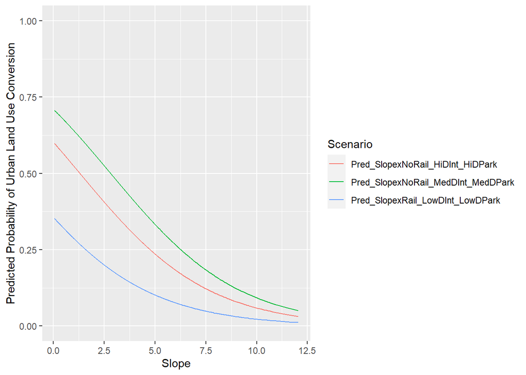

```r
####Plot Predicted Change in probability of Urban Land Conversion based on Slope

#Scenario1: Slope by >300m from rail (0), 12530m (median) distance from interstate, 5161m (median) distance from parks
newdat_gg<-data.frame(matrix(ncol = 4, nrow = nrow(Dat_H)))
colnames(newdat_gg)<- c("SLOPE", "REGRAIL300", "DIST_INTER", "DIST_PARKS")
newdat_gg$SLOPE <- Dat_H$SLOPE
newdat_gg$REGRAIL300 <- 0
newdat_gg$DIST_INTER <- 12530
newdat_gg$DIST_PARKS <- 5161

#Scenario2: Slope by <300m from rail (1), 5590m (Q1) distance from interstate, 2500m (Q1) distance from parks
newdat_gg_1<-data.frame(matrix(ncol = 4, nrow = nrow(Dat_H)))
colnames(newdat_gg_1)<- c("SLOPE", "REGRAIL300", "DIST_INTER", "DIST_PARKS")
newdat_gg_1$SLOPE <- Dat_H$SLOPE
newdat_gg_1$REGRAIL300 <- 1
newdat_gg_1$DIST_INTER <- 5590
newdat_gg_1$DIST_PARKS <- 2500

#Scenario3: Slope by >300m from rail (0), 24076m (Q3) distance from interstate, 7106m (Q3) distance from parks
newdat_gg_2<-data.frame(matrix(ncol = 4, nrow = nrow(Dat_H)))
colnames(newdat_gg_2)<- c("SLOPE", "REGRAIL300", "DIST_INTER", "DIST_PARKS")
newdat_gg_2$SLOPE <- Dat_H$SLOPE
newdat_gg_2$REGRAIL300 <- 1
newdat_gg_2$DIST_INTER <- 24076
newdat_gg_2$DIST_PARKS <- 7106


pred_dat<- data.frame(matrix(ncol = 4, nrow = nrow(Dat_H)))
colnames(pred_dat)<- c("SLOPE", "Pred_SlopexNoRail_MedDInt_MedDPark", "Pred_SlopexRail_LowDInt_LowDPark", "Pred_SlopexNoRail_HiDInt_HiDPark")
pred_dat$SLOPE<-Dat_H$SLOPE
pred_dat$Pred_SlopexNoRail_MedDInt_MedDPark<- predict(ML_Model7, newdat_gg, type="response")
pred_dat$Pred_SlopexRail_LowDInt_LowDPark<- predict(ML_Model7, newdat_gg_1, type="response")
pred_dat$Pred_SlopexNoRail_HiDInt_HiDPark<- predict(ML_Model7, newdat_gg_2, type="response")

dat <- gather(pred_dat, -SLOPE, key = "Scenario", value = "value")

ggplot(dat, aes(x = SLOPE, y = value, colour = Scenario)) +
        geom_line() + ylim(0,1) +
        xlab("Slope") + ylab("Predicted Probability of Urban Land Use Conversion")
```

# Part B: Transportation Mode Choice with Logit Models

In the second part of this assignment, we use binomial and multinomial logit models to explore how a person’s household, demographic, and trip characteristics affect their choice of transportation mode to work using data from the DVRPC Household Travel Survey (HHTS).

Section B.1 uses binomial logit models to explore the relationships between those who drive alone to work and household, demographic, and trip characteristics vs. those who do not drive alone to work.

Section B.2 also uses binomial logit models, but this time to compare walking and biking choice to other modes against similar characteristics.

Section B.3 uses multinomial logit models to explain whether someone drove, carpooled, took public transit, or walked/biked to work.

# B.1 Driving Alone to Work vs. Other Modes

In this section, we develop a binomial LOGIT model to explain whether a commuter drove to work or used another mode.

```r
rm(list=ls())

per_dat <- read_csv("https://raw.githubusercontent.com/c-townsley/pbn_a3_repo/main/Data/HH%20Travel%20Survey/per_pub.csv")

trip_dat <- read_csv("https://raw.githubusercontent.com/c-townsley/pbn_a3_repo/main/Data/HH%20Travel%20Survey/trip_pub.csv")

hh_dat <- read_csv("https://raw.githubusercontent.com/c-townsley/pbn_a3_repo/main/Data/HH%20Travel%20Survey/hh_pub_CSV.csv", col_names = TRUE)
```

## B.1A Processing and Exploration

First, we create a dataframe that combines household and person level information.

```r
# Develop a dataset with all relevant variables

# Want to look at the person_dat, but also want to include income, which is in the HH table.
# matching the datasets on HH ID number, which is the variable "SAMPN"
per_hh_dat <- merge(per_dat, hh_dat,
                    by.x = "SAMPN", #per_dat is the x
                    by.y = "SAMPN", #hh_dat is the y
                    all.x = TRUE,   #taking every row of X and finding the matching Y
                    all.y = FALSE,  #Exclude rows in hh_dat that don't have a matching value in per_dat
                    sort = FALSE)

#select variables of interest
per_hh_clean <- per_hh_dat %>%
  dplyr::select(SAMPN, PERNO, GEND, AGE, INCOM, W1CPK, W1EPK, TRNST, VTRAN, TRNCT, WSTIM, WETIM)

#combine SAMPN and PERNO
per_hh_clean$SAMPN_PER <- paste0(per_hh_clean$SAMPN, per_hh_clean$PERNO)

#remove NAs
per_hh_clean$INCOM[which(is.na(per_hh_clean$INCOM))]<-0
per_hh_clean$TRNCT[which(is.na(per_hh_clean$TRNCT))] <- 0

head(per_hh_clean)
```

```
##     SAMPN PERNO GEND AGE INCOM W1CPK W1EPK TRNST VTRAN TRNCT WSTIM WETIM
## 1 1000024     1    1  50    10     0     2     2    NA     0   900  1600
## 2 1000024     2    2  45    10     0     1     2    NA     0   700  1600
## 3 1000054     1    2  60     6     0     2     2    NA     0   830  1515
## 4 1000054     2    1  64     6    NA    NA    NA    NA     0    NA    NA
## 5 1000175     1    2  65     6     0     2     2    NA     0   900  1700
## 6 1000175     2    1  37     6    NA    NA    NA    NA     0    NA    NA
##   SAMPN_PER
## 1  10000241
## 2  10000242
## 3  10000541
## 4  10000542
## 5  10001751
## 6  10001752
```

After selecting our variables of interest, we have a dataset with 10,391 observations and 13 variables.

Next we explore our trip data.

```r
head(trip_dat,10)
```

```
## # A tibble: 10 × 76
##      SAMPN PERNO     ...3 PLANO ATIME DTIME TRPDUR ACTDUR Origin_PTYPE Dest_PTYE
##      <dbl> <dbl>    <dbl> <dbl> <dbl> <dbl>  <dbl>  <dbl>        <dbl>     <dbl>
##  1 1000018     1 10000181     1   300   630     NA    210           NA         1
##  2 1000018     1 10000181     2   800   830     90     30            1         2
##  3 1000018     1 10000181     3   900  1000     30     60            2         5
##  4 1000018     1 10000181     4  1040  1135     40     55            5         2
##  5 1000018     1 10000181     5  1200  1300     25     60            2         5
##  6 1000018     1 10000181     6  1415  1525     75     70            5         5
##  7 1000018     1 10000181     7  1538  1630     13     52            5         5
##  8 1000018     1 10000181     8  1739  1900     69     81            5         5
##  9 1000018     1 10000181     9  1930   259     30    449            5         1
## 10 1000018     2 10000182     1   300   259     NA   1439            1         1
## # ℹ 66 more variables: PLOC <dbl>, ...12 <lgl>, ACT1 <dbl>,
## #   `Work/NotWork` <dbl>, Origin <dbl>, Mode <dbl>, TT <dbl>, ACT2 <dbl>,
## #   ACT3 <dbl>, ACT4 <dbl>, ACT5 <dbl>, ACT6 <dbl>, ACT1O <lgl>, ACTO <lgl>,
## #   TRAN1 <dbl>, TRAN2 <dbl>, TRAN3 <dbl>, TRAN4 <lgl>, OTRAN <lgl>,
## #   HHVU <dbl>, HHVNO <dbl>, ADP <dbl>, TOTTRAV <dbl>, NTRAV <dbl>,
## #   NHTRV <dbl>, PHHTR <chr>, NNHTR <dbl>, PARK <dbl>, PARKO <lgl>,
## #   PARKC <dbl>, PARKU <dbl>, PRKUO <lgl>, TOLL <dbl>, TOLLA <dbl>, …
```

So many variables! Let’s look at the breakdown of transmit modes for the first, second, and third transit modes respondents took to work.

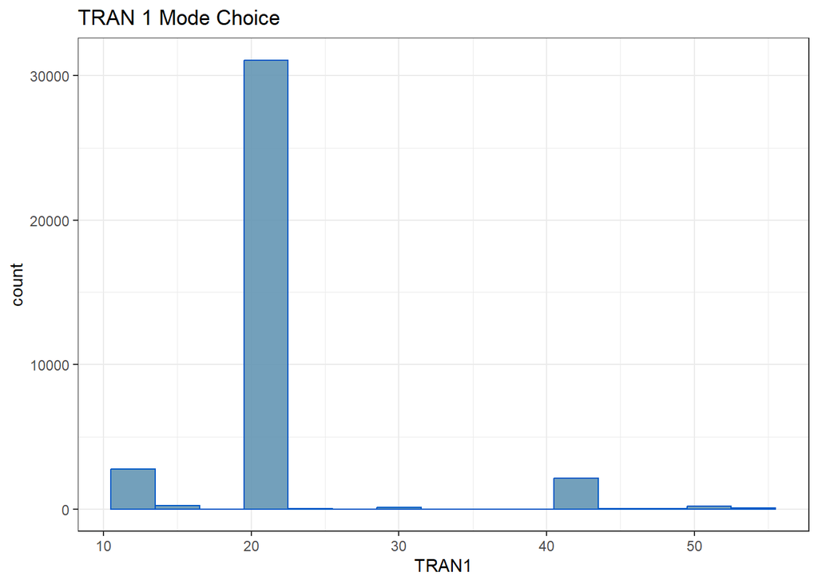

```r
trip_dat %>%
  filter(TRAN1 < 55) %>%
ggplot( aes(x=TRAN1)) +
    geom_histogram( binwidth=3, fill="#6496b4", color="#0059c7", alpha=0.9) +
    ggtitle("TRAN 1 Mode Choice") +
    theme_bw()
```

```r
print("TRAN1 Summary")
```

```
## [1] "TRAN1 Summary"
```

```r
summary(trip_dat$TRAN1)
```

```
##    Min. 1st Qu.  Median    Mean 3rd Qu.    Max.    NA's
##   11.00   21.00   21.00   21.95   22.00   98.00   10392
```

Graphing and summarizing the first trip mode (`TRAN1`) shows that most people are driving themselves to work (code 21) but a noticeable amount of people are walking or biking (codes 11-14).

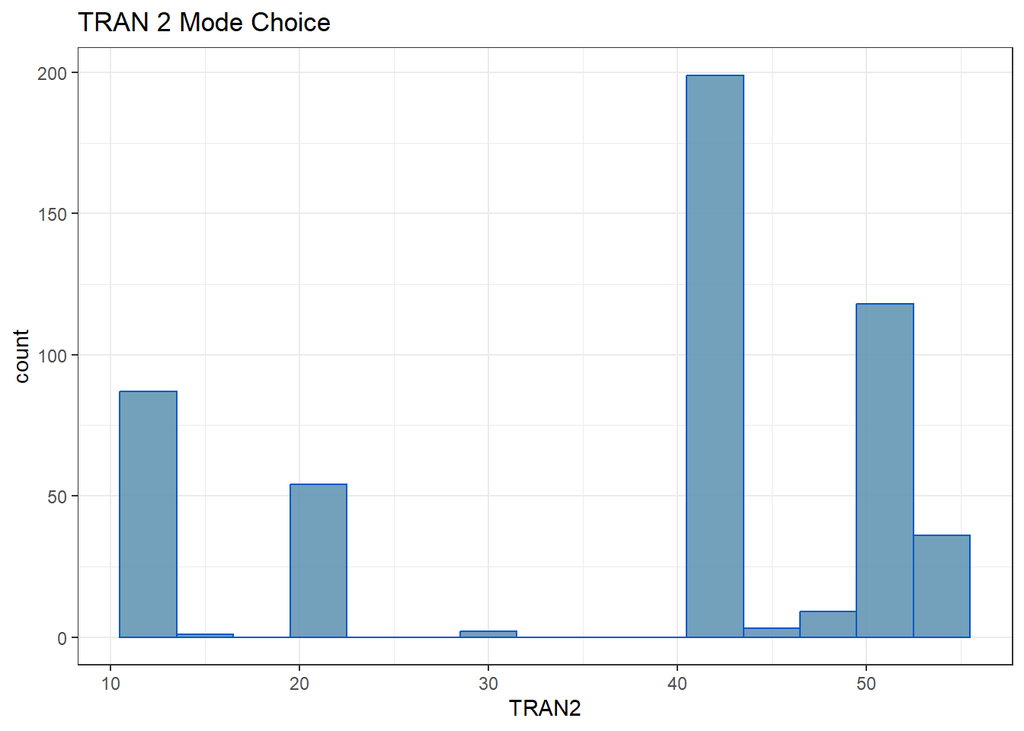

```r
trip_dat %>%
    filter(TRAN2 < 60) %>%
ggplot( aes(x=TRAN2)) +
    geom_histogram( binwidth=3, fill="#6496b4", color="#0059c7", alpha=0.9) +
    ggtitle("TRAN 2 Mode Choice") +
    theme_bw()
```

```r
print("TRAN2 Summary")
```

```
## [1] "TRAN2 Summary"
```

```r
summary(trip_dat$TRAN2)
```

```
##    Min. 1st Qu.  Median    Mean 3rd Qu.    Max.    NA's
##   11.00   22.00   41.00   37.72   51.00   97.00   46559
```

For mode 2, we see that more people are walking or biking and more people are taking transit (codes 40-53).

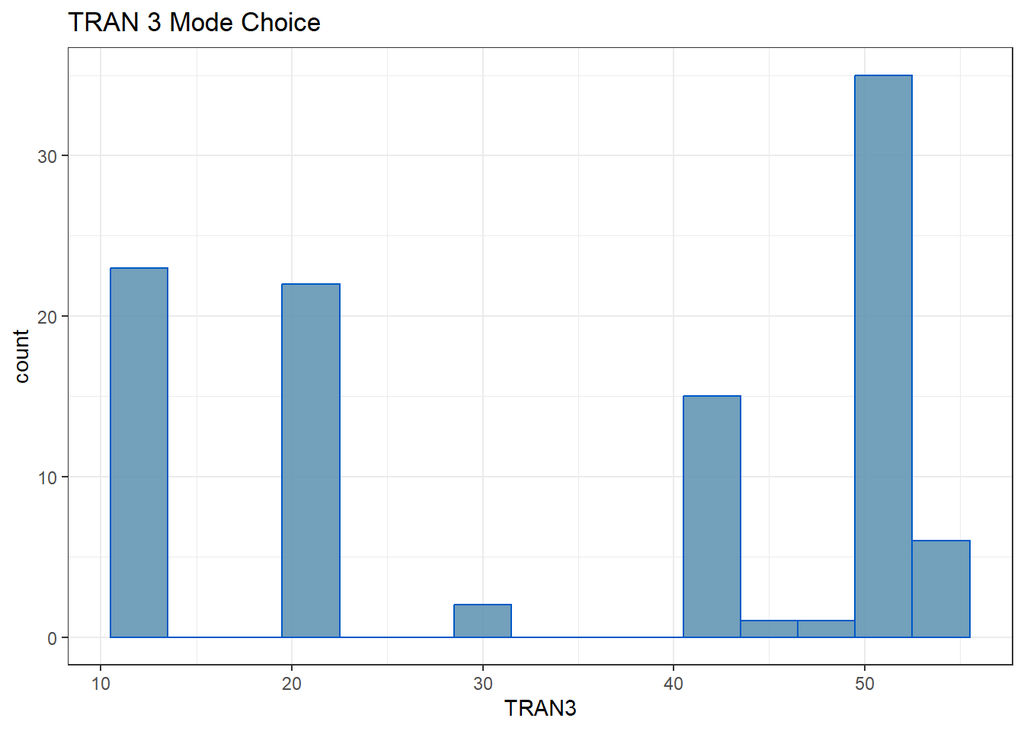

```r
trip_dat %>%
    filter(TRAN3 < 60) %>%
ggplot( aes(x=TRAN3)) +
    geom_histogram( binwidth=3, fill="#6496b4", color="#0059c7", alpha=0.9) +
    ggtitle("TRAN 3 Mode Choice") +
    theme_bw()
```

```r
print("TRAN3 Summary")
```

```
## [1] "TRAN3 Summary"
```

```r
summary(trip_dat$TRAN3)
```

```
##    Min. 1st Qu.  Median    Mean 3rd Qu.    Max.    NA's
##   11.00   21.00   41.00   34.99   51.00   97.00   46966
```

And we see that the third mode is more variable.

Next, we pull out those that drove alone to work during their first work trip and narrow the data down to our key variables of interest.

```r
#grab anyone who drives alone to work on their first one-way work trip of the day
trip_dat$drivealone[(trip_dat$TRAN1==21 | trip_dat$TRAN2==21 |
                       trip_dat$TRAN3==21| trip_dat$TRAN4==21)] <-1
trip_dat$drivealone[which(is.na(trip_dat$drivealone))] <-0 #Remove NAs

#now let's pick out that first work trip
CommuteTripsClean <- trip_dat[which(trip_dat$Dest_PTYE == 2), ]

#let's merge in on person number and SAMPN
#we have to merge together the SAMPN and the person number
#There is an X variable in the data frame already.
#We can replicate this column by concatenating SAMPB and PERNO
CommuteTripsClean$SAMPN_PER <- paste0(CommuteTripsClean$SAMPN, CommuteTripsClean$PERNO)

#grab just the first work trip
CommuteTripsClean <- subset(CommuteTripsClean, !duplicated(SAMPN_PER))

#Retain just the columns we need from the trip data.
CommuteTripsClean2 <- CommuteTripsClean %>%
  dplyr::select(SAMPN, PERNO, SAMPN_PER, TOLLA, TOLL, PARKC, PARKU, TRPDUR, drivealone)

#remove NAs
CommuteTripsClean2$TOLLA[which(is.na(CommuteTripsClean2$TOLLA))]<-0
CommuteTripsClean2$TOLL[which(is.na(CommuteTripsClean2$TOLL))]<-0
CommuteTripsClean2$PARKU[which(is.na(CommuteTripsClean2$PARKU))]<-0
CommuteTripsClean2$PARKC[which(is.na(CommuteTripsClean2$PARKC))]<-0

#remove trips with a duration of zero
CommuteTripsClean2 <- CommuteTripsClean2 %>%
  filter(TRPDUR != 0)

head(CommuteTripsClean2)
```

```
## # A tibble: 6 × 9
##     SAMPN PERNO SAMPN_PER TOLLA  TOLL PARKC PARKU TRPDUR drivealone
##     <dbl> <dbl> <chr>     <dbl> <dbl> <dbl> <dbl>  <dbl>      <dbl>
## 1 1000018     1 10000181      0     2     0     0     90          1
## 2 1000024     2 10000242      0     2     0     0     25          1
## 3 1000054     1 10000541      0     2     0     0      5          1
## 4 1000212     2 10002122      0     2     0     0     60          1
## 5 1000239     1 10002391      0     2     0     0     37          1
## 6 1000244     1 10002441      0     2     0     0      3          1
```

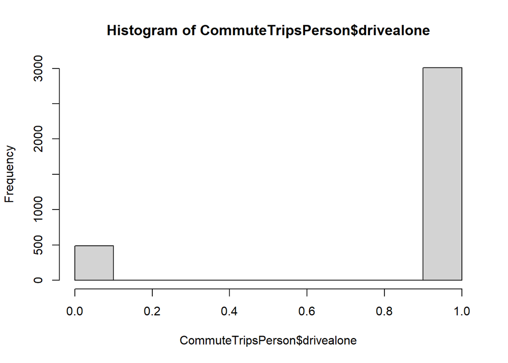

```r
#Merge CommuteTripsClean2 with per_hh_clean via SAMPN_PER
CommuteTripsPerson <- merge(CommuteTripsClean2,
                            per_hh_clean,
                            by.x = "SAMPN_PER",
                            by.y = "SAMPN_PER",
                            all.x = TRUE,
                            all.y = FALSE,
                            sort = FALSE)

hist(CommuteTripsPerson$drivealone)
```

We see that many more people in this subset drove alone to work than walked or biked.

## B.1B Variable Selection

Now, we select the variables we are most interested in testing with our models.

The binomial Dependent Variable for our model is `drivealone`: Which is whether the person alone drove to work vs. got to work any other way.

Our independent variables of interest are: * `GEND`: Person X - Gender * `AGE`: Person X - Age * `INCOM`: total 1999 annual household income * `TRPDUR`: trip duration * `TOLL`: presence of toll (Y/N) * `TOLLA`: toll amount * `PARKC`: parking cost ($) * `PARKU`: parking cost unit (per hour, day, week, month, or other) * `TRNCT`: Cost of Using Transit (dollar figure)

The values for `GEND`, `TOLL`, and `PARKU` are categorical, so we need to turn them into binary dummy variables to be able to use them in our models.

```r
#Create dummy variables from GEND, TOLL, and PARKU
CommuteTripsPerson <- CommuteTripsPerson %>%
  mutate(GEND_M = ifelse(GEND == 1, 1, 0)) %>% #create binary for male drivers
  mutate(GEND_F = ifelse(GEND == 2, 1, 0)) %>% #create binary for female drivers
  mutate(TOLL = ifelse(TOLL == 1, 1, 0)) %>% #create binary for tolls
  mutate(PARKU_H = ifelse(PARKU == 1, 1, 0)) %>% #create binary for hourly parking
  mutate(PARKU_D = ifelse(PARKU == 2, 1, 0)) %>% #create binary for daily parking
  mutate(PARKU_W = ifelse(PARKU == 3, 1, 0)) %>% #create binary for weekly parking
  mutate(PARKU_M = ifelse(PARKU == 4, 1, 0)) #create binary for monthly parking

head(CommuteTripsPerson)
```

```
##   SAMPN_PER SAMPN.x PERNO.x TOLLA TOLL PARKC PARKU TRPDUR drivealone SAMPN.y
## 1  10000181 1000018       1     0    0     0     0     90          1 1000018
## 2  10000242 1000024       2     0    0     0     0     25          1 1000024
## 3  10000541 1000054       1     0    0     0     0      5          1 1000054
## 4  10002122 1000212       2     0    0     0     0     60          1 1000212
## 5  10002391 1000239       1     0    0     0     0     37          1 1000239
## 6  10002441 1000244       1     0    0     0     0      3          1 1000244
##   PERNO.y GEND AGE INCOM W1CPK W1EPK TRNST VTRAN TRNCT WSTIM WETIM GEND_M
## 1       1    1  60     0  0.25     2     8    NA   4.5   730  1900      1
## 2       2    2  45    10  0.00     1     2    NA   0.0   700  1600      0
## 3       1    2  60     6  0.00     2     2    NA   0.0   830  1515      0
## 4       2    2  45     9 90.00     2     2    NA 265.0   800  1800      0
## 5       1    2  34     4  0.00     1     2    NA   0.0   800  1600      0
## 6       1    1  38     9  0.00     2     2    NA   0.0   230  1700      1
##   GEND_F PARKU_H PARKU_D PARKU_W PARKU_M
## 1      0       0       0       0       0
## 2      1       0       0       0       0
## 3      1       0       0       0       0
## 4      1       0       0       0       0
## 5      1       0       0       0       0
## 6      0       0       0       0       0
```

```
## [1] "Cost of Using Transit"
```

```
## [1] -0.2029331
```

```
## [1] "Presence of Toll"
```

```
## [1] 0.08811121
```

```
## [1] "Trip Duration"
```

```
## [1] -0.084159
```

```
## [1] "Toll Amount"
```

```
## [1] 0.07635734
```

```
## [1] "Daily Parking"
```

```
## [1] 0.04594193
```

```
## [1] "Income"
```

```
## [1] 0.04066905
```

```
## [1] "Gender - Female"
```

```
## [1] -0.0726196
```

```
## [1] "Gender - Male"
```

```
## [1] 0.07238951
```

```
## [1] "Monthly Parking"
```

```
## [1] 0.04103817
```

```
## [1] "Parking Cost"
```

```
## [1] 0.02408251
```

```
## [1] "Age"
```

```
## [1] 0.01504652
```

```
## [1] "Hourly Parking"
```

```
## [1] 0.01802068
```

```
## [1] "Weekly Parking"
```

```
## [1] 0.01179054
```

Let’s test these variables for colinearity with the dependent variable and each other using a correlation plot.

```r
#make matrix of variables we're testing
mod_A_vars <- CommuteTripsPerson %>%
  dplyr::select(drivealone, TOLL, TOLLA, TRPDUR, INCOM, GEND_F, GEND_M, AGE, PARKC, PARKU_H, PARKU_D, PARKU_W, PARKU_M, TRNCT)

#r clear Nans and Inf values
mod_A_vars[sapply(mod_A_vars, is.na)] <- 0
mod_A_vars[sapply(mod_A_vars, is.nan)] <- 0
mod_A_vars[sapply(mod_A_vars, is.infinite)] <- 0

#Check for NAs
any(is.na(mod_A_vars))
```

```
## [1] FALSE
```

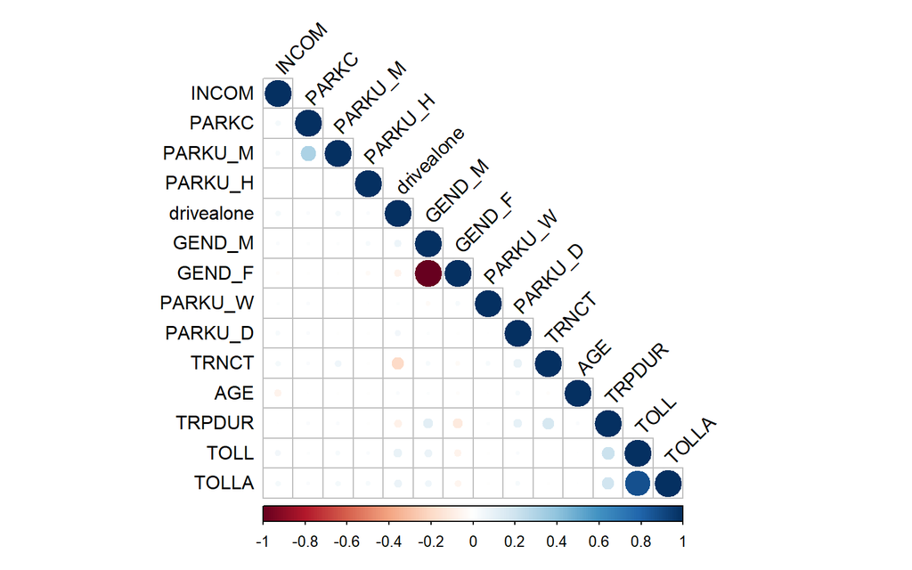

```r
#compute correlation matrix
cormatrix2 <- cor(mod_A_vars) %>%
  round(., 2)

#plot a correlogram
corrplot(cormatrix2, method = "circle", type = "lower", order = "hclust",
         tl.col = "black", tl.srt = 45)
```

This plot shows that the presence of a toll and toll amount exhibit correlation with each other, meaning that their inclusion in the model is mutually exclusive. Unsurprisingly, the same is true for male and female drivers. We pick the presence of a toll (`TOLL`) and female drivers (`GEND_F`) to include in our models, because they are more correlated with drive alone trips than their closely correlated pair.

This yields our final list of 11 independent variables to include in our models: * `GEND_F`: Female commuter * `AGE`: Age of commuter * `INCOM`: total 1999 annual household income * `TRPDUR`: trip duration * `TOLL`: presence of toll * `PARKC`: parking cost ($) * `PARKU_H`: parking priced per hour * `PARKU_D`: parking priced per day * `PARKU_W`: parking priced per week * `PARKU_M`: parking priced per month * `TRNCT`: Cost of Using Transit (dollar figure)

## B.1C Develop Binomial Logit Model

We develop a binomial logit model to to understand the factors that influence the binary outcome of whether or not someone drove alone to work and to make predictions about the probability of them doing so in the future based on our independent variables of interest.

Crucially, we are trying to determine which of these indepdendent variables have the most predictive relevance.

To do so, we first create a baseline model, called `mod_A`, that includes all of our variables of interest.

```r
mod_A <- glm ( drivealone ~ AGE + GEND_F + TRPDUR + INCOM + TOLL + PARKC +
                PARKU_H + PARKU_D + PARKU_W + PARKU_M + TRNCT,
               data=CommuteTripsPerson, family = binomial)
print("mod_A")
```

```
## [1] "mod_A"
```

```r
summary(mod_A)
```

```
##
## Call:
## glm(formula = drivealone ~ AGE + GEND_F + TRPDUR + INCOM + TOLL +
##     PARKC + PARKU_H + PARKU_D + PARKU_W + PARKU_M + TRNCT, family = binomial,
##     data = CommuteTripsPerson)
##
## Deviance Residuals:
##     Min       1Q   Median       3Q      Max
## -2.3543   0.4118   0.4902   0.5562   5.2709
##
## Coefficients:
##               Estimate Std. Error z value Pr(>|z|)
## (Intercept)  2.171e+00  1.528e-01  14.209  < 2e-16 ***
## AGE          2.976e-04  5.443e-04   0.547   0.5845
## GEND_F      -4.920e-01  1.048e-01  -4.696 2.65e-06 ***
## TRPDUR      -9.588e-03  2.378e-03  -4.032 5.54e-05 ***
## INCOM        4.766e-02  1.881e-02   2.534   0.0113 *
## TOLL         2.014e+01  2.176e+03   0.009   0.9926
## PARKC        3.165e+00  7.624e+01   0.042   0.9669
## PARKU_H      1.879e+01  1.022e+04   0.002   0.9985
## PARKU_D      1.755e+01  3.380e+03   0.005   0.9959
## PARKU_W      9.983e+00  1.064e+04   0.001   0.9993
## PARKU_M      6.464e+00  2.289e+03   0.003   0.9977
## TRNCT       -1.897e-02  1.897e-03  -9.999  < 2e-16 ***
## ---
## Signif. codes:  0 '***' 0.001 '**' 0.01 '*' 0.05 '.' 0.1 ' ' 1
##
## (Dispersion parameter for binomial family taken to be 1)
##
##     Null deviance: 2817.8  on 3491  degrees of freedom
## Residual deviance: 2561.0  on 3480  degrees of freedom
## AIC: 2585
##
## Number of Fisher Scoring iterations: 20
```

We see that many of the variables included in `mod_A` lack significance but four of our predictor variables - `GEND_F`, `TRPDUR`, `INCOM`, `TRNCT` - appear to be significant predictors of driving alone to work.

The AIC is 2585. The null deviance is high at 2817.8, indicating a poor fit. But the residual deviance is lower at 2561.0, which indicates that the model explains a significant amount of the variance in the response variable.

Let’s try to whittle these down with automated backwards selection using `drop1`.

```r
#Use drop1 to decide which variables to remove
#LRT shows the change in deviance, so a large LRT and small p-value means we should keep the variable in the model, and a small LRT and/or large p-value means cut it
drop1(mod_A, test="Chisq")
```

```
## Single term deletions
##
## Model:
## drivealone ~ AGE + GEND_F + TRPDUR + INCOM + TOLL + PARKC + PARKU_H +
##     PARKU_D + PARKU_W + PARKU_M + TRNCT
##         Df Deviance    AIC     LRT  Pr(>Chi)
## <none>       2561.0 2585.0
## AGE      1   2561.3 2583.3   0.320   0.57135
## GEND_F   1   2583.5 2605.5  22.529  2.07e-06 ***
## TRPDUR   1   2578.2 2600.2  17.214  3.34e-05 ***
## INCOM    1   2567.3 2589.3   6.314   0.01198 *
## TOLL     1   2616.2 2638.2  55.180  1.10e-13 ***
## PARKC    1   2562.6 2584.6   1.553   0.21264
## PARKU_H  1   2561.9 2583.9   0.951   0.32939
## PARKU_D  1   2561.0 2583.0   0.000   1.00000
## PARKU_W  1   2561.0 2583.0   0.000   1.00000
## PARKU_M  1   2561.0 2583.0   0.000   1.00000
## TRNCT    1   2676.4 2698.4 115.373 < 2.2e-16 ***
## ---
## Signif. codes:  0 '***' 0.001 '**' 0.01 '*' 0.05 '.' 0.1 ' ' 1
```

Running `drop1` gives us some useful information. We see that the model with `GEND_F`, `TRPDUR`, `INCOM`, `TOLL`, and `TRNCT` as predictor variables are significant as they result in a significant increase in deviance and AIC values when dropped from the full model.

Their large LRT and small p-value further indicate their significance.

Therefore, we run a new model with just `GEND_F`, `TRPDUR`, `INCOM`, `TOLL`, and `TRNCT` based on these results.

```r
mod_B <- glm ( drivealone ~  GEND_F + TRPDUR + INCOM + TOLL + TRNCT,
               data=CommuteTripsPerson, family = binomial)
summary(mod_B)
```

```
##
## Call:
## glm(formula = drivealone ~ GEND_F + TRPDUR + INCOM + TOLL + TRNCT,
##     family = binomial, data = CommuteTripsPerson)
##
## Deviance Residuals:
##     Min       1Q   Median       3Q      Max
## -2.3036   0.4193   0.4925   0.5526   4.8091
##
## Coefficients:
##               Estimate Std. Error z value Pr(>|z|)
## (Intercept)   2.163733   0.145489  14.872  < 2e-16 ***
## GEND_F       -0.481216   0.103735  -4.639  3.5e-06 ***
## TRPDUR       -0.008791   0.002322  -3.786 0.000153 ***
## INCOM         0.050436   0.018472   2.730 0.006324 **
## TOLL         16.017434 301.953818   0.053 0.957695
## TRNCT        -0.016255   0.001732  -9.386  < 2e-16 ***
## ---
## Signif. codes:  0 '***' 0.001 '**' 0.01 '*' 0.05 '.' 0.1 ' ' 1
##
## (Dispersion parameter for binomial family taken to be 1)
##
##     Null deviance: 2817.8  on 3491  degrees of freedom
## Residual deviance: 2611.3  on 3486  degrees of freedom
## AIC: 2623.3
##
## Number of Fisher Scoring iterations: 16
```

Interestingly, in this new model, all of the variables are significant except `TOLL`. We also see that the AIC has increased by 38 and the residual deviance has increased by 50, indicating a slightly poorer fit.

Let’s see what happens if we run one more model without `TOLL`.

```r
mod_C <- glm ( drivealone ~ GEND_F + TRPDUR + INCOM + TRNCT, data=CommuteTripsPerson, family = binomial)
summary(mod_C)
```

```
##
## Call:
## glm(formula = drivealone ~ GEND_F + TRPDUR + INCOM + TRNCT, family = binomial,
##     data = CommuteTripsPerson)
##
## Deviance Residuals:
##     Min       1Q   Median       3Q      Max
## -2.3230   0.4181   0.4895   0.5488   4.7626
##
## Coefficients:
##              Estimate Std. Error z value Pr(>|z|)
## (Intercept)  2.158161   0.143610  15.028  < 2e-16 ***
## GEND_F      -0.517420   0.103306  -5.009 5.48e-07 ***
## TRPDUR      -0.006443   0.002159  -2.985  0.00284 **
## INCOM        0.053466   0.018342   2.915  0.00356 **
## TRNCT       -0.016094   0.001671  -9.634  < 2e-16 ***
## ---
## Signif. codes:  0 '***' 0.001 '**' 0.01 '*' 0.05 '.' 0.1 ' ' 1
##
## (Dispersion parameter for binomial family taken to be 1)
##
##     Null deviance: 2817.8  on 3491  degrees of freedom
## Residual deviance: 2665.1  on 3487  degrees of freedom
## AIC: 2675.1
##
## Number of Fisher Scoring iterations: 4
```

In this third model, all of the variables are significant, but the AIC has increased by 52 and the residual deviance increased by 54 from model 2, indicating a slightly worse fit.

## B1.D Model Selection

To determine which model to select as our final model, we compare the fit of the three models with ANOVA.

```r
anova(mod_A, mod_B, mod_C, test="Chisq")
```

```
## Analysis of Deviance Table
##
## Model 1: drivealone ~ AGE + GEND_F + TRPDUR + INCOM + TOLL + PARKC + PARKU_H +
##     PARKU_D + PARKU_W + PARKU_M + TRNCT
## Model 2: drivealone ~ GEND_F + TRPDUR + INCOM + TOLL + TRNCT
## Model 3: drivealone ~ GEND_F + TRPDUR + INCOM + TRNCT
##   Resid. Df Resid. Dev Df Deviance  Pr(>Chi)
## 1      3480     2561.0
## 2      3486     2611.3 -6  -50.254 4.182e-09 ***
## 3      3487     2665.1 -1  -53.796 2.224e-13 ***
## ---
## Signif. codes:  0 '***' 0.001 '**' 0.01 '*' 0.05 '.' 0.1 ' ' 1
```

Because this model achieved this by removing the `PARKC`, `PARKU_H`, `PARKU_D`, `PARKU_W`, and `PARKU_M` variables, it is both our leanest, and meanest model.

```r
stargazer(mod_A, mod_B, mod_C, type="html", digits = 2, single.row = FALSE)
```

|  | *Dependent variable:* |  |  |
| --- | --- | --- | --- |
|  | drivealone |  |  |
|  | (1) | (2) | (3) |
| AGE | 0.0003 |  |  |
|  | (0.001) |  |  |
| GEND_F | -0.49*** | -0.48*** | -0.52*** |
|  | (0.10) | (0.10) | (0.10) |
| TRPDUR | -0.01*** | -0.01*** | -0.01*** |
|  | (0.002) | (0.002) | (0.002) |
| INCOM | 0.05** | 0.05*** | 0.05*** |
|  | (0.02) | (0.02) | (0.02) |
| TOLL | 20.14 | 16.02 |  |
|  | (2,176.38) | (301.95) |  |
| PARKC | 3.17 |  |  |
|  | (76.24) |  |  |
| PARKU_H | 18.79 |  |  |
|  | (10,215.42) |  |  |
| PARKU_D | 17.55 |  |  |
|  | (3,380.37) |  |  |
| PARKU_W | 9.98 |  |  |
|  | (10,635.85) |  |  |
| PARKU_M | 6.46 |  |  |
|  | (2,288.96) |  |  |
| TRNCT | -0.02*** | -0.02*** | -0.02*** |
|  | (0.002) | (0.002) | (0.002) |
| Constant | 2.17*** | 2.16*** | 2.16*** |
|  | (0.15) | (0.15) | (0.14) |
| Observations | 3,492 | 3,492 | 3,492 |
| Log Likelihood | -1,280.50 | -1,305.63 | -1,332.53 |
| Akaike Inf. Crit. | 2,585.00 | 2,623.26 | 2,675.05 |
| *Note:* | p<0.1; p<0.05; p<0.01 |  |  |

Comparing the models with a stargazer table helps us see that the AIC increase of 90 is comparitively slight, and worth the trade off of a model that has solely significant variables.

## B.1E Interpret Final Model Results

**Prediction Accuracy**

```r
predC <- as.data.frame(fitted(mod_C))
predC <- rename(predC, "prob" = "fitted(mod_C)")
predC <- mutate(predC, "binary" = ifelse(prob < 0.5, 0, 1)) #if predicted probabilities are <0.5, then classify as zero, otherwise classify as 1

#append column to original data frame
CommuteTripsPerson$binary <- predC$binary

#accuracy rate
(sum(CommuteTripsPerson$drivealone == 1 & CommuteTripsPerson$binary == 1) +
    sum(CommuteTripsPerson$drivealone == 0 & CommuteTripsPerson$binary == 0)) /
  nrow(CommuteTripsPerson)
```

```
## [1] 0.8591065
```

Calculating our model’s prediction accuracy gives us an accuracy rate of 86% - pretty good!

**Interpret coefficients**

```r
#if exp(coef) = .8:  a unit increase in X is associated with
#a 20% decline in the odds ratio
#if exp(coef)  = 1.5:  a unit increase in X is associated with
#a 50% increase in the odds ratio
#percent change in the odds ratio
100 * (exp(coef(mod_C))-1)
```

```
## (Intercept)      GEND_F      TRPDUR       INCOM       TRNCT
##  765.520334  -40.394371   -0.642265    5.492137   -1.596551
```

The coefficients of our model suggest that: * The odds ratio of a person driving alone to work is 40.4% *lower* if they are female.  
* a unit increase in trip duration *decreases* the odds ratio of someone driving alone to work by 0.6%.  
* a unit increase in income *increases* the odds ratio of a person driving alone to work by 5.5%.  
* And a unit increase in transit cost *decreases* the odds ratio of a person driving alone to work by 1.6%.

The chart below shows that even as trip duration increases, the odds ratio of a person driving alone to work continues to be lower if they are female.

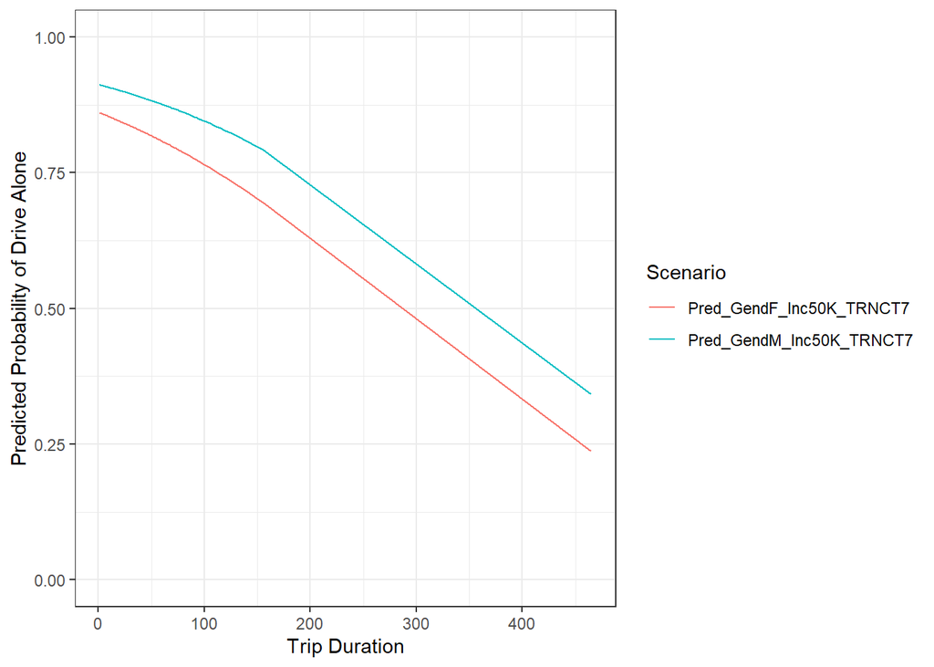

```r
mod_gg1 <- data.frame(matrix(ncol = 4, nrow = nrow(CommuteTripsPerson)))
colnames(mod_gg1) <- c("TRPDUR", "INCOM", "GEND_F", "TRNCT")
mod_gg1$TRPDUR <- CommuteTripsPerson$TRPDUR
mod_gg1$INCOM <- mean(CommuteTripsPerson$INCOM)
mod_gg1$GEND_F <- 1
mod_gg1$TRNCT <- mean(CommuteTripsPerson$TRNCT)

mod_gg2 <- data.frame(matrix(ncol = 4, nrow = nrow(CommuteTripsPerson)))
colnames(mod_gg2) <- c("TRPDUR", "INCOM", "GEND_F", "TRNCT")
mod_gg2$TRPDUR <- CommuteTripsPerson$TRPDUR
mod_gg2$INCOM <- mean(CommuteTripsPerson$INCOM)
mod_gg2$GEND_F <- 0
mod_gg2$TRNCT <- mean(CommuteTripsPerson$TRNCT)

#Predict results based on models
pred_dat <- data.frame(matrix(ncol = 3, nrow = nrow(CommuteTripsPerson)))
colnames(pred_dat) <- c("TRPDUR", "Pred_GendF_Inc50K_TRNCT7", "Pred_GendM_Inc50K_TRNCT7")
pred_dat$TRPDUR <- CommuteTripsPerson$TRPDUR
#store predicted probabilities in new column
pred_dat$Pred_GendF_Inc50K_TRNCT7 <- predict(mod_C, mod_gg1, type="response")
pred_dat$Pred_GendM_Inc50K_TRNCT7 <- predict(mod_C, mod_gg2, type="response")

pred_dat_wd <- pred_dat %>%
  pivot_longer(!TRPDUR, names_to = "Scenario")

ggplot(pred_dat_wd, aes(x = TRPDUR, y = value, colour = Scenario)) +
        geom_line() + ylim(0,1) +
        xlab("Trip Duration") + ylab("Predicted Probability of Drive Alone") +
  theme_bw()
```

In summary, these models suggest that the gender of a driver, the duration of their trip, their income, and the cost of using transit are the most important predictors of whether they will drive alone to work. These findings seem reasonable. In the U.S., women still share an unequal burden of childcare compared to men. Additionally, the gender pay gap could be a factor, since income appears to be a significant predictor of driving alone as well. It is intuitive that a longer trip could also encourage car-pooling or other modes, as it changes the cost-benefit ratio of driving alone or driving all together.

Our finding that higher transit cost decreases the odds ratio that a person will drive alone to work was surprising however. Intuitively, it would seem that cheap transit would increase the attractiveness of this mode. This finding suggests that future study of the variables and their interactions is necessary.

We found that the cost of parking, and whether commuters pay hourly, daily, weekly, or monthly are of secondary importance. It is not surprising that these supply-side factors had a secondary effect on the attractiveness of driving. In our correlation tests, it was interesting, to see that daily parking had a higher and positive correlation with driving alone than the other parking cost units (hourly, weekly, or monthly). This could be because daily parkers have more erratic commuting patterns than other commuters and therefore are more likely to drive alone when they do drive.

# B.2 Walking or Biking to Work vs. Using Other Modes

> Develop a second binomial LOGIT model explaining whether a commuter walked/biked to work or used another mode. Use any and all independent variables you think appropriate, including dummy variables.

## B.2A Data Exploration and Processing

```r
#grab anyone who walked or biked to work on their first one-way work trip of the day
trip_dat$walkbike[(trip_dat$TRAN1==11 | trip_dat$TRAN2==11 |
                       trip_dat$TRAN3==11| trip_dat$TRAN4==11 |
                     trip_dat$TRAN1==14 | trip_dat$TRAN2==14 |
                       trip_dat$TRAN3==14| trip_dat$TRAN4==14 )] <-1
trip_dat$walkbike[which(is.na(trip_dat$walkbike))] <-0 #Remove NAs

#now let's pick out that first work trip
CommuteTripsClean <- trip_dat[which(trip_dat$Dest_PTYE == 2), ]

#let's merge in on person number and SAMPN
#we have to merge together the SAMPN and the person number
#There is an X variable in the data frame already.
#We can replicate this column by concatenating SAMPB and PERNO
CommuteTripsClean$SAMPN_PER <- paste0(CommuteTripsClean$SAMPN, CommuteTripsClean$PERNO)

#grab just the first work trip
CommuteTripsClean <- subset(CommuteTripsClean, !duplicated(SAMPN_PER))

#Retain just the columns we need from the trip data.
CommuteTrips_walkbike <- CommuteTripsClean %>%
  dplyr::select(SAMPN, PERNO, SAMPN_PER, TOLLA, TOLL, PARKC, PARKU, TRPDUR, walkbike)

#remove trips with a duration of zero
CommuteTrips_walkbike <- CommuteTrips_walkbike %>%
  filter(TRPDUR != 0)

glimpse(CommuteTrips_walkbike)
```

```
## Rows: 3,492
## Columns: 9
## $ SAMPN     <dbl> 1000018, 1000024, 1000054, 1000212, 1000239, 1000244, 100024…
## $ PERNO     <dbl> 1, 2, 1, 2, 1, 1, 2, 1, 2, 1, 2, 1, 2, 1, 2, 1, 2, 4, 1, 1, …
## $ SAMPN_PER <chr> "10000181", "10000242", "10000541", "10002122", "10002391", …
## $ TOLLA     <dbl> NA, NA, NA, NA, NA, NA, NA, NA, NA, NA, NA, NA, NA, NA, NA, …
## $ TOLL      <dbl> 2, 2, 2, 2, 2, 2, 2, 2, 2, 2, 2, 2, 2, 2, 2, 2, 2, 2, 2, 2, …
## $ PARKC     <dbl> 0, 0, 0, 0, 0, 0, 0, 0, 0, 0, 0, 0, 0, 0, 0, 0, 0, 0, 0, 0, …
## $ PARKU     <dbl> NA, NA, NA, NA, NA, NA, NA, NA, NA, NA, NA, NA, NA, NA, NA, …
## $ TRPDUR    <dbl> 90, 25, 5, 60, 37, 3, 30, 15, 10, 40, 40, 25, 15, 15, 30, 40…
## $ walkbike  <dbl> 0, 0, 0, 0, 0, 0, 0, 0, 0, 0, 0, 0, 0, 0, 0, 0, 0, 0, 0, 0, …
```

```r
summary(CommuteTrips_walkbike)
```

```
##      SAMPN             PERNO        SAMPN_PER             TOLLA
##  Min.   :1000018   Min.   :1.000   Length:3492        Min.   :0.250
##  1st Qu.:1033318   1st Qu.:1.000   Class :character   1st Qu.:0.875
##  Median :1082178   Median :1.000   Mode  :character   Median :2.600
##  Mean   :1064452   Mean   :1.629                      Mean   :2.045
##  3rd Qu.:1087968   3rd Qu.:2.000                      3rd Qu.:3.000
##  Max.   :1108535   Max.   :9.000                      Max.   :6.000
##                                                       NA's   :3337
##       TOLL           PARKC             PARKU          TRPDUR
##  Min.   :1.000   Min.   :  0.000   Min.   :1.00   Min.   :  1.00
##  1st Qu.:2.000   1st Qu.:  0.000   1st Qu.:2.00   1st Qu.: 15.00
##  Median :2.000   Median :  0.000   Median :2.00   Median : 23.00
##  Mean   :1.947   Mean   :  1.695   Mean   :3.01   Mean   : 27.24
##  3rd Qu.:2.000   3rd Qu.:  0.000   3rd Qu.:4.00   3rd Qu.: 35.00
##  Max.   :2.000   Max.   :900.000   Max.   :7.00   Max.   :465.00
##  NA's   :489     NA's   :516       NA's   :3395
##     walkbike
##  Min.   :0.0000
##  1st Qu.:0.0000
##  Median :0.0000
##  Mean   :0.0547
##  3rd Qu.:0.0000
##  Max.   :1.0000
##
```

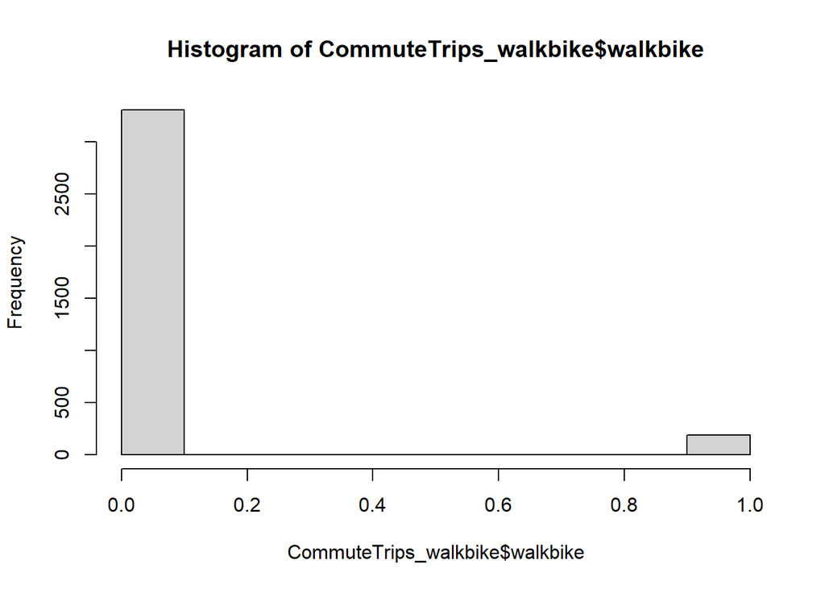

```r
hist(CommuteTrips_walkbike$walkbike)
```

```r
#Merge CommuteTrips_walkbike with per_hh_clean via SAMPN_PER
CommuteTrips_walkbike <- merge(CommuteTrips_walkbike,
                            per_hh_clean,
                            by.x = "SAMPN_PER",
                            by.y = "SAMPN_PER",
                            all.x = TRUE,
                            all.y = FALSE,
                            sort = FALSE)
```

## B.2B Variable Selection

The binomial Dependent Variable for our model is `walkbike`: Which is whether the person walked or cycled to work vs. got to work any other way.

The values for `GEND`, `TOLL`, and `PARKU` are categorical, so we need to turn them into binary dummy variables to be able to use them in our models.

```r
#Create dummy variables from GEND, TOLL, and PARKU
CommuteTrips_walkbike <- CommuteTrips_walkbike %>%
  mutate(GEND_M = ifelse(GEND == 1, 1, 0)) %>% #create binary for male drivers
  mutate(GEND_F = ifelse(GEND == 2, 1, 0)) %>% #create binary for female drivers
  mutate(TOLL = ifelse(TOLL == 1, 1, 0)) %>% #create binary for tolls
  mutate(PARKU_H = ifelse(PARKU == 1, 1, 0)) %>% #create binary for hourly parking
  mutate(PARKU_D = ifelse(PARKU == 2, 1, 0)) %>% #create binary for daily parking
  mutate(PARKU_W = ifelse(PARKU == 3, 1, 0)) %>% #create binary for weekly parking
  mutate(PARKU_M = ifelse(PARKU == 4, 1, 0)) #create binary for monthly parking
```

Independent variables of interest: * `GEND`: Person X - Gender * `AGE`: Person X - Age * `INCOM`: total 1999 annual household income * `TRPDUR`: trip duration * `TOLL`: presence of toll (Y/N) * `TOLLA`: toll amount * `PARKC`: parking cost ($) * `PARKU`: parking cost unit (per hour, day, week, month, or other) * `TRNCT`: Cost of Using Transit (dollar figure)

```r
summary(CommuteTrips_walkbike)
```

```
##   SAMPN_PER            SAMPN.x           PERNO.x          TOLLA
##  Length:3492        Min.   :1000018   Min.   :1.000   Min.   :0.250
##  Class :character   1st Qu.:1033318   1st Qu.:1.000   1st Qu.:0.875
##  Mode  :character   Median :1082178   Median :1.000   Median :2.600
##                     Mean   :1064452   Mean   :1.629   Mean   :2.045
##                     3rd Qu.:1087968   3rd Qu.:2.000   3rd Qu.:3.000
##                     Max.   :1108535   Max.   :9.000   Max.   :6.000
##                                                       NA's   :3337
##       TOLL            PARKC             PARKU          TRPDUR
##  Min.   :0.0000   Min.   :  0.000   Min.   :1.00   Min.   :  1.00
##  1st Qu.:0.0000   1st Qu.:  0.000   1st Qu.:2.00   1st Qu.: 15.00
##  Median :0.0000   Median :  0.000   Median :2.00   Median : 23.00
##  Mean   :0.0533   Mean   :  1.695   Mean   :3.01   Mean   : 27.24
##  3rd Qu.:0.0000   3rd Qu.:  0.000   3rd Qu.:4.00   3rd Qu.: 35.00
##  Max.   :1.0000   Max.   :900.000   Max.   :7.00   Max.   :465.00
##  NA's   :489      NA's   :516       NA's   :3395
##     walkbike         SAMPN.y           PERNO.y           GEND
##  Min.   :0.0000   Min.   :1000018   Min.   :1.000   Min.   :1.000
##  1st Qu.:0.0000   1st Qu.:1033318   1st Qu.:1.000   1st Qu.:1.000
##  Median :0.0000   Median :1082178   Median :1.000   Median :2.000
##  Mean   :0.0547   Mean   :1064452   Mean   :1.629   Mean   :1.505
##  3rd Qu.:0.0000   3rd Qu.:1087968   3rd Qu.:2.000   3rd Qu.:2.000
##  Max.   :1.0000   Max.   :1108535   Max.   :9.000   Max.   :9.000
##
##       AGE             INCOM            W1CPK             W1EPK
##  Min.   : 16.00   Min.   : 0.000   Min.   :  0.000   Min.   :1.000
##  1st Qu.: 36.00   1st Qu.: 5.000   1st Qu.:  0.000   1st Qu.:2.000
##  Median : 45.00   Median : 6.000   Median :  0.000   Median :2.000
##  Mean   : 55.53   Mean   : 5.557   Mean   :  3.928   Mean   :2.286
##  3rd Qu.: 53.00   3rd Qu.: 7.000   3rd Qu.:  0.000   3rd Qu.:2.000
##  Max.   :999.00   Max.   :10.000   Max.   :900.000   Max.   :9.000
##                                    NA's   :193       NA's   :74
##      TRNST           VTRAN           TRNCT             WSTIM
##  Min.   :1.000   Min.   :1.000   Min.   :  0.000   Min.   : 110
##  1st Qu.:2.000   1st Qu.:1.000   1st Qu.:  0.000   1st Qu.: 730
##  Median :2.000   Median :1.000   Median :  0.000   Median : 800
##  Mean   :2.511   Mean   :1.447   Mean   :  6.985   Mean   :1149
##  3rd Qu.:2.000   3rd Qu.:2.000   3rd Qu.:  0.000   3rd Qu.: 900
##  Max.   :9.000   Max.   :8.000   Max.   :850.000   Max.   :9999
##                  NA's   :3237
##      WETIM          GEND_M           GEND_F          PARKU_H
##  Min.   : 100   Min.   :0.0000   Min.   :0.0000   Min.   :0.000
##  1st Qu.:1600   1st Qu.:0.0000   1st Qu.:0.0000   1st Qu.:0.000
##  Median :1700   Median :0.0000   Median :1.0000   Median :0.000
##  Mean   :1945   Mean   :0.4974   Mean   :0.5023   Mean   :0.072
##  3rd Qu.:1800   3rd Qu.:1.0000   3rd Qu.:1.0000   3rd Qu.:0.000
##  Max.   :9999   Max.   :1.0000   Max.   :1.0000   Max.   :1.000
##                                                   NA's   :3395
##     PARKU_D         PARKU_W         PARKU_M
##  Min.   :0.000   Min.   :0.000   Min.   :0.000
##  1st Qu.:0.000   1st Qu.:0.000   1st Qu.:0.000
##  Median :0.000   Median :0.000   Median :0.000
##  Mean   :0.464   Mean   :0.031   Mean   :0.371
##  3rd Qu.:1.000   3rd Qu.:0.000   3rd Qu.:1.000
##  Max.   :1.000   Max.   :1.000   Max.   :1.000
##  NA's   :3395    NA's   :3395    NA's   :3395
```

Remove some outliers and NAs

```r
CommuteTrips_walkbike <-CommuteTrips_walkbike[which(CommuteTrips_walkbike$AGE %in% 1:110),]
CommuteTrips_walkbike <-CommuteTrips_walkbike[which(CommuteTrips_walkbike$TRPDUR %in% 0:400),]

CommuteTrips_walkbike$W1CPK[which(is.na(CommuteTrips_walkbike$W1CPK))] <-0
CommuteTrips_walkbike$PARKU_H[which(is.na(CommuteTrips_walkbike$PARKU_H))] <-0
CommuteTrips_walkbike$PARKU_D[which(is.na(CommuteTrips_walkbike$PARKU_D))] <-0
CommuteTrips_walkbike$PARKU_W[which(is.na(CommuteTrips_walkbike$PARKU_W))] <-0
CommuteTrips_walkbike$PARKU_M[which(is.na(CommuteTrips_walkbike$PARKU_M))] <-0

CommuteTrips_walkbike[sapply(CommuteTrips_walkbike, is.na)] <- 0
CommuteTrips_walkbike[sapply(CommuteTrips_walkbike, is.nan)] <- 0
CommuteTrips_walkbike[sapply(CommuteTrips_walkbike, is.infinite)] <- 0
```

```r
print("Cost of Using Transit")
```

```
## [1] "Cost of Using Transit"
```

```r
cor(CommuteTrips_walkbike$walkbike, CommuteTrips_walkbike$TRNCT, use="complete.obs", method="pearson")
```

```
## [1] 0.146626
```

```r
print("Cost to Park at Work")
```

```
## [1] "Cost to Park at Work"
```

```r
cor(CommuteTrips_walkbike$walkbike, CommuteTrips_walkbike$W1CPK, use="complete.obs", method="pearson")
```

```
## [1] 0.04906913
```

```r
print("Age")
```

```
## [1] "Age"
```

```r
cor(CommuteTrips_walkbike$walkbike, CommuteTrips_walkbike$AGE, use="complete.obs", method="pearson")
```

```
## [1] -0.04220161
```

```r
print("Trip Duration")
```

```
## [1] "Trip Duration"
```

```r
cor(CommuteTrips_walkbike$walkbike, CommuteTrips_walkbike$TRPDUR, use="complete.obs", method="pearson")
```

```
## [1] -0.03245712
```

```r
print("Daily Parking")
```

```
## [1] "Daily Parking"
```

```r
cor(CommuteTrips_walkbike$walkbike, CommuteTrips_walkbike$PARKU_D, use="complete.obs", method="pearson")
```

```
## [1] 0.03078588
```

```r
print("Income")
```

```
## [1] "Income"
```

```r
cor(CommuteTrips_walkbike$walkbike, CommuteTrips_walkbike$INCOM, use="complete.obs", method="pearson")
```

```
## [1] -0.02912378
```

```r
print("Presence of Toll")
```

```
## [1] "Presence of Toll"
```

```r
cor(CommuteTrips_walkbike$walkbike, CommuteTrips_walkbike$TOLL, use="complete.obs", method="pearson")
```

```
## [1] -0.05247785
```

```r
print("Monthly Parking")
```

```
## [1] "Monthly Parking"
```

```r
cor(CommuteTrips_walkbike$walkbike, CommuteTrips_walkbike$PARKU_M, use="complete.obs", method="pearson")
```

```
## [1] -0.01199917
```

```r
print("Hourly Parking")
```

```
## [1] "Hourly Parking"
```

```r
cor(CommuteTrips_walkbike$walkbike, CommuteTrips_walkbike$PARKU_H, use="complete.obs", method="pearson")
```

```
## [1] -0.0108007
```

```r
print("Weekly Parking")
```

```
## [1] "Weekly Parking"
```

```r
cor(CommuteTrips_walkbike$walkbike, CommuteTrips_walkbike$PARKU_W, use="complete.obs", method="pearson")
```

```
## [1] -0.007066615
```

```r
print("Gender - Female")
```

```
## [1] "Gender - Female"
```

```r
cor(CommuteTrips_walkbike$walkbike, CommuteTrips_walkbike$GEND_F, use="complete.obs", method="pearson")
```

```
## [1] 0.004875035
```

```r
print("Gender - Male")
```

```
## [1] "Gender - Male"
```

```r
cor(CommuteTrips_walkbike$walkbike, CommuteTrips_walkbike$GEND_M, use="complete.obs", method="pearson")
```

```
## [1] -0.004875035
```

```r
print("Parking Cost")
```

```
## [1] "Parking Cost"
```

```r
cor(CommuteTrips_walkbike$walkbike, CommuteTrips_walkbike$PARKC, use="complete.obs", method="pearson")
```

```
## [1] -0.01363818
```

Overall, there doesn’t seem to be a lot of correlation between these variables and walking or biking to work, especially when exdluding the cost of using transit.

Let’s test these variables for colinearity with the dependent variable and each other using a correlation plot.

```r
#make matrix of variables we're testing
mod_Aa_vars <- CommuteTrips_walkbike %>%
  dplyr::select(walkbike, TOLL, TRPDUR, INCOM, GEND_F, GEND_M, AGE, PARKC, PARKU_H, PARKU_D, PARKU_W, PARKU_M, TRNCT, W1CPK)

#r clear Nans and Inf values
mod_Aa_vars[sapply(mod_Aa_vars, is.na)] <- 0
mod_Aa_vars[sapply(mod_Aa_vars, is.nan)] <- 0
mod_Aa_vars[sapply(mod_Aa_vars, is.infinite)] <- 0

any(is.na(mod_Aa_vars))
```

```
## [1] FALSE
```

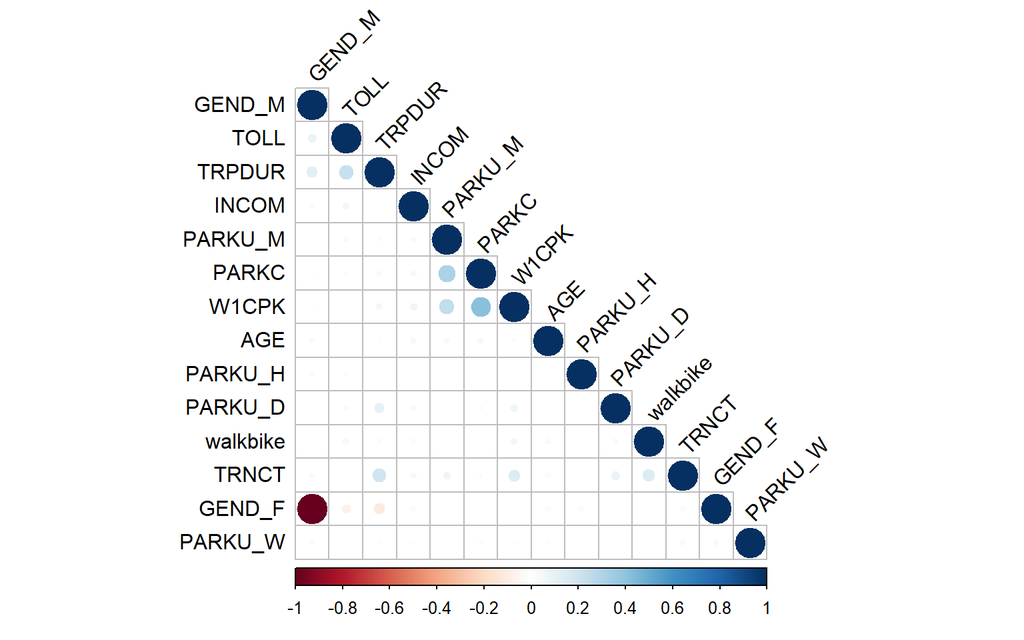

```r
#compute correlation matrix
cormatrix3 <- cor(mod_Aa_vars) %>%
  round(., 2)

#plot a correlogram
corrplot(cormatrix3, method = "circle", type = "lower", order = "hclust",
         tl.col = "black", tl.srt = 45)
```

## B.2C Develop Binomial Logit Model

First, we create a baseline model, called `mod_Aa`, that includes all of our variables of interest.

```r
mod_Aa <- glm ( walkbike ~ AGE + GEND_F + TRPDUR + INCOM + TOLL + PARKC +
                PARKU_H + PARKU_D + PARKU_W + PARKU_M + TRNCT + W1CPK,
               data=CommuteTrips_walkbike, family = binomial)
print("mod_Aa")
```

```
## [1] "mod_Aa"
```

```r
summary(mod_Aa)
```

```
##
## Call:
## glm(formula = walkbike ~ AGE + GEND_F + TRPDUR + INCOM + TOLL +
##     PARKC + PARKU_H + PARKU_D + PARKU_W + PARKU_M + TRNCT + W1CPK,
##     family = binomial, data = CommuteTrips_walkbike)
##
## Deviance Residuals:
##     Min       1Q   Median       3Q      Max
## -4.0348  -0.3493  -0.3093  -0.2686   2.7312
##
## Coefficients:
##               Estimate Std. Error z value Pr(>|z|)
## (Intercept) -1.638e+00  3.452e-01  -4.746 2.08e-06 ***
## AGE         -1.485e-02  6.119e-03  -2.427  0.01521 *
## GEND_F      -8.058e-03  1.547e-01  -0.052  0.95845
## TRPDUR      -1.396e-02  4.559e-03  -3.061  0.00221 **
## INCOM       -6.569e-02  2.840e-02  -2.313  0.02070 *
## TOLL        -1.539e+01  5.003e+02  -0.031  0.97546
## PARKC       -3.315e-01  2.059e-01  -1.610  0.10736
## PARKU_H     -1.538e+01  2.357e+03  -0.007  0.99479
## PARKU_D      1.824e+00  6.806e-01   2.680  0.00736 **
## PARKU_W     -1.246e+01  2.379e+03  -0.005  0.99582
## PARKU_M      2.518e+00  1.680e+00   1.499  0.13381
## TRNCT        1.337e-02  2.081e-03   6.427 1.30e-10 ***
## W1CPK        3.092e-03  1.507e-03   2.051  0.04025 *
## ---
## Signif. codes:  0 '***' 0.001 '**' 0.01 '*' 0.05 '.' 0.1 ' ' 1
##
## (Dispersion parameter for binomial family taken to be 1)
##
##     Null deviance: 1453.7  on 3447  degrees of freedom
## Residual deviance: 1361.8  on 3435  degrees of freedom
## AIC: 1387.8
##
## Number of Fisher Scoring iterations: 17
```

We see that many of the variables included in `mod_Aa` lack significance.

Let’s try to whittle these down with automated backwards selection using `drop1`.

```r
#Use drop1 to decide which variables to remove
#LRT shows the change in deviance, so a large LRT and small p-value means we should keep the variable in the model, and a small LRT and/or large p-value means cut it
drop1(mod_Aa, test="Chisq")
```

```
## Single term deletions
##
## Model:
## walkbike ~ AGE + GEND_F + TRPDUR + INCOM + TOLL + PARKC + PARKU_H +
##     PARKU_D + PARKU_W + PARKU_M + TRNCT + W1CPK
##         Df Deviance    AIC    LRT  Pr(>Chi)
## <none>       1361.8 1387.8
## AGE      1   1367.7 1391.7  5.895 0.0151842 *
## GEND_F   1   1361.8 1385.8  0.003 0.9584560
## TRPDUR   1   1372.2 1396.2 10.412 0.0012522 **
## INCOM    1   1367.0 1391.0  5.184 0.0227953 *
## TOLL     1   1374.9 1398.9 13.069 0.0003003 ***
## PARKC    1   1369.3 1393.3  7.424 0.0064359 **
## PARKU_H  1   1362.5 1386.5  0.611 0.4343083
## PARKU_D  1   1368.0 1392.0  6.138 0.0132304 *
## PARKU_W  1   1361.9 1385.9  0.033 0.8552009
## PARKU_M  1   1363.9 1387.9  2.040 0.1532326
## TRNCT    1   1404.0 1428.0 42.168 8.378e-11 ***
## W1CPK    1   1365.4 1389.4  3.548 0.0596031 .
## ---
## Signif. codes:  0 '***' 0.001 '**' 0.01 '*' 0.05 '.' 0.1 ' ' 1
```

Running `drop1` gives us some useful information. We see that if we drop no variables from the model, the AIC is 1387.8. Furthermore, we want to keep variables in the model that have a large LRT and small p-value (suggesting statistical significance).

We run a new model with just `AGE`, `TRPDUR`, `INCOM`, `TOLL`, `PARKC`, `PARKU_D`, `TRNCT`, and `W1CPK` based on these results.

```r
mod_Bb <- glm (walkbike ~  AGE + TRPDUR + INCOM + TOLL + PARKC + PARKU_D + TRNCT + W1CPK,
               data=CommuteTrips_walkbike, family = binomial)
summary(mod_Bb)
```

```
##
## Call:
## glm(formula = walkbike ~ AGE + TRPDUR + INCOM + TOLL + PARKC +
##     PARKU_D + TRNCT + W1CPK, family = binomial, data = CommuteTrips_walkbike)
##
## Deviance Residuals:
##     Min       1Q   Median       3Q      Max
## -4.0596  -0.3492  -0.3100  -0.2697   2.8934
##
## Coefficients:
##               Estimate Std. Error z value Pr(>|z|)
## (Intercept)  -1.649516   0.330155  -4.996 5.85e-07 ***
## AGE          -0.014722   0.006112  -2.409  0.01602 *
## TRPDUR       -0.014015   0.004551  -3.079  0.00207 **
## INCOM        -0.064997   0.028400  -2.289  0.02210 *
## TOLL        -15.403035 501.134927  -0.031  0.97548
## PARKC        -0.180122   0.134430  -1.340  0.18028
## PARKU_D       1.458666   0.652341   2.236  0.02535 *
## TRNCT         0.013496   0.002082   6.481 9.12e-11 ***
## W1CPK         0.003118   0.001504   2.073  0.03814 *
## ---
## Signif. codes:  0 '***' 0.001 '**' 0.01 '*' 0.05 '.' 0.1 ' ' 1
##
## (Dispersion parameter for binomial family taken to be 1)
##
##     Null deviance: 1453.7  on 3447  degrees of freedom
## Residual deviance: 1364.6  on 3439  degrees of freedom
## AIC: 1382.6
##
## Number of Fisher Scoring iterations: 17
```

Good news, We see that the AIC has gone down slightly and just two variables, `TOLL` and `PARKC` appear to not be significant. So we run a new model without them.

```r
mod_Cc <- glm (walkbike ~  AGE + TRPDUR + INCOM + PARKU_D + TRNCT + W1CPK,
               data=CommuteTrips_walkbike, family = binomial)
summary(mod_Cc)
```

```
##
## Call:
## glm(formula = walkbike ~ AGE + TRPDUR + INCOM + PARKU_D + TRNCT +
##     W1CPK, family = binomial, data = CommuteTrips_walkbike)
##
## Deviance Residuals:
##     Min       1Q   Median       3Q      Max
## -4.0605  -0.3465  -0.3049  -0.2654   2.7805
##
## Coefficients:
##              Estimate Std. Error z value Pr(>|z|)
## (Intercept) -1.584050   0.329775  -4.803 1.56e-06 ***
## AGE         -0.015827   0.006135  -2.580 0.009888 **
## TRPDUR      -0.016323   0.004541  -3.595 0.000324 ***
## INCOM       -0.068057   0.028223  -2.411 0.015889 *
## PARKU_D      0.848901   0.504780   1.682 0.092622 .
## TRNCT        0.013592   0.002002   6.789 1.13e-11 ***
## W1CPK        0.002283   0.001316   1.734 0.082847 .
## ---
## Signif. codes:  0 '***' 0.001 '**' 0.01 '*' 0.05 '.' 0.1 ' ' 1
##
## (Dispersion parameter for binomial family taken to be 1)
##
##     Null deviance: 1453.7  on 3447  degrees of freedom
## Residual deviance: 1385.5  on 3441  degrees of freedom
## AIC: 1399.5
##
## Number of Fisher Scoring iterations: 6
```

```r
mod_Dd <- glm (walkbike ~  AGE + TRPDUR + INCOM + TRNCT,
               data=CommuteTrips_walkbike, family = binomial)
summary(mod_Dd)
```

```
##
## Call:
## glm(formula = walkbike ~ AGE + TRPDUR + INCOM + TRNCT, family = binomial,
##     data = CommuteTrips_walkbike)
##
## Deviance Residuals:
##     Min       1Q   Median       3Q      Max
## -4.2163  -0.3465  -0.3060  -0.2685   2.7721
##
## Coefficients:
##              Estimate Std. Error z value Pr(>|z|)
## (Intercept) -1.630826   0.329306  -4.952 7.33e-07 ***
## AGE         -0.015493   0.006124  -2.530 0.011416 *
## TRPDUR      -0.015217   0.004460  -3.412 0.000645 ***
## INCOM       -0.063083   0.028114  -2.244 0.024844 *
## TRNCT        0.014307   0.001992   7.184 6.79e-13 ***
## ---
## Signif. codes:  0 '***' 0.001 '**' 0.01 '*' 0.05 '.' 0.1 ' ' 1
##
## (Dispersion parameter for binomial family taken to be 1)
##
##     Null deviance: 1453.7  on 3447  degrees of freedom
## Residual deviance: 1390.3  on 3443  degrees of freedom
## AIC: 1400.3
##
## Number of Fisher Scoring iterations: 6
```

This raised the AIC by less than 1 and now all of the variables in our model are significant. Therefore, our fourth model appears to give us comparable results with the fewest variables.

## B.2D Interpret Model Results

To confirm our selection of the fourth model as the best one, we compare the fit of all four models with ANOVA.

```r
anova(mod_Aa, mod_Bb, mod_Cc, mod_Dd, test="Chisq")
```

```
## Analysis of Deviance Table
##
## Model 1: walkbike ~ AGE + GEND_F + TRPDUR + INCOM + TOLL + PARKC + PARKU_H +
##     PARKU_D + PARKU_W + PARKU_M + TRNCT + W1CPK
## Model 2: walkbike ~ AGE + TRPDUR + INCOM + TOLL + PARKC + PARKU_D + TRNCT +
##     W1CPK
## Model 3: walkbike ~ AGE + TRPDUR + INCOM + PARKU_D + TRNCT + W1CPK
## Model 4: walkbike ~ AGE + TRPDUR + INCOM + TRNCT
##   Resid. Df Resid. Dev Df Deviance  Pr(>Chi)
## 1      3435     1361.8
## 2      3439     1364.6 -4  -2.7421   0.60187
## 3      3441     1385.5 -2 -20.9300 2.852e-05 ***
## 4      3443     1390.3 -2  -4.7951   0.09094 .
## ---
## Signif. codes:  0 '***' 0.001 '**' 0.01 '*' 0.05 '.' 0.1 ' ' 1
```

Therefore, we select our third model as our final model, instead of our fourth.

**Prediction Accuracy**

```r
predW <- as.data.frame(fitted(mod_Cc))
predW <- rename(predW, "prob" = "fitted(mod_Cc)")
predW <- mutate(predW, "binary" = ifelse(prob < 0.5, 0, 1)) #if predicted probabilities are <0.5, then classify as zero, otherwise classify as 1

#append column to original data frame
CommuteTrips_walkbike$binary <- predW$binary

#accuracy rate
(sum(CommuteTrips_walkbike$walkbike == 1 & CommuteTrips_walkbike$binary == 1) +
    sum(CommuteTrips_walkbike$walkbike == 0 & CommuteTrips_walkbike$binary == 0)) /
  nrow(CommuteTrips_walkbike)
```

```
## [1] 0.9446056
```

Calculating our model’s prediction accuracy gives us an accuracy rate of 94% this time!

```r
#false positives - predict that the person drove but actually didn't
print("False Positives")
```

```
## [1] "False Positives"
```

```r
sum(CommuteTrips_walkbike$walkbike == 0 & CommuteTrips_walkbike$binary == 1)
```

```
## [1] 5
```

```r
#false negatives - predict that the person didn't drive but actually did
print("False Negatives")
```

```
## [1] "False Negatives"
```

```r
sum(CommuteTrips_walkbike$walkbike == 1 & CommuteTrips_walkbike$binary == 0)
```

```
## [1] 186
```

We see that the model seems to somewhat under predict the likelihood people will walk or bike to work.

```r
modelChiDd <- mod_Dd$null.deviance - mod_Dd$deviance
modelChiDd
```

```
## [1] 63.36333
```

**Interpret coefficients**

```r
#if exp(coef) = .8:  a unit increase in X is associated with
#a 20% decline in the odds ratio
#if exp(coef)  = 1.5:  a unit increase in X is associated with
#a 50% increase in the odds ratio
#percent change in the odds ratio
100 * (exp(coef(mod_Cc))-1)
```

```
## (Intercept)         AGE      TRPDUR       INCOM     PARKU_D       TRNCT
## -79.4857490  -1.5702570  -1.6190693  -6.5793054 133.7077850   1.3685159
##       W1CPK
##   0.2285463
```

The coefficients of our model suggest that: * A unit increase in a person’s age *decreases* the odds ratio that they will walk or bike to work by 1.6%. * A unit increase in trip duration also *decreases* the odds ratio of a person walking or biking to work by 1.6%.  
* A a unit increase in a person’s income *decreases* the odds ratio that they will walk or bike to work by 6.6%.  
* The odds ratio of a person walking or biking to work *increases* by 133.7% if they pay for parking by day as opposed to by hour, week, or month. * A unit increase in transit cost *increases* the odds ratio of a person walking or biking to work by 1.4%. * A unit increase in the cost of parking a vehicle at work *increases* the odds ratio of a person walking or biking to work by 0.2%.

It is important to note that based on our models, that age, trip duration, transit cost, and income seem to be the most significant factors related to whether a person walks or bikes to work.

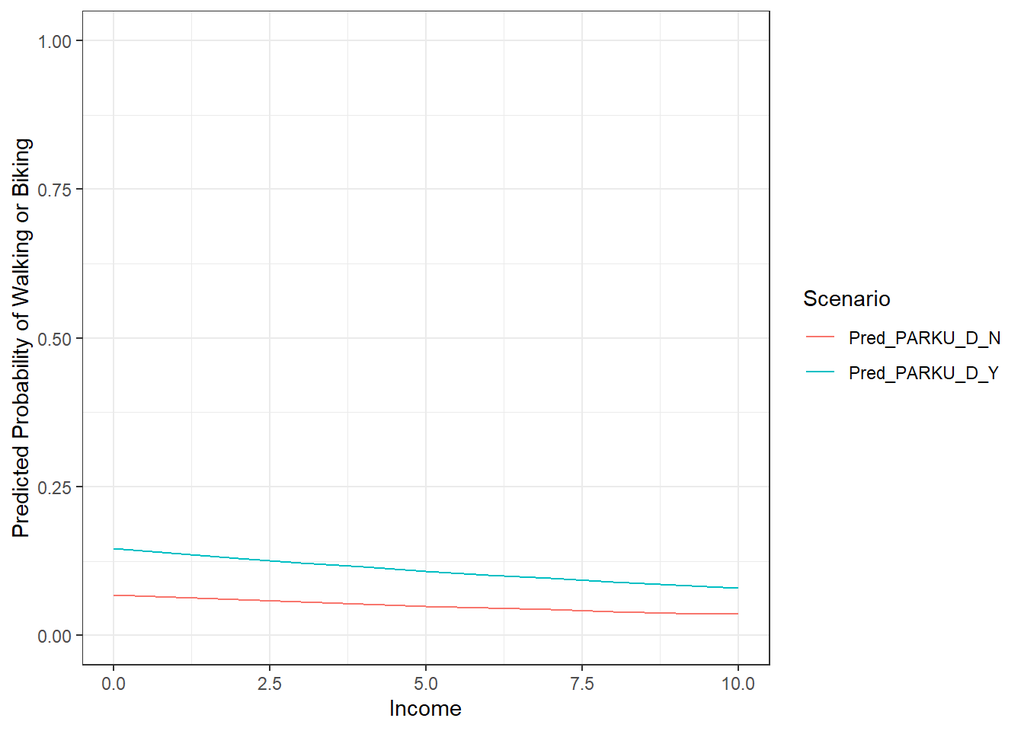

```r
mod_gg3 <- data.frame(matrix(ncol = 6, nrow = nrow(CommuteTrips_walkbike)))
colnames(mod_gg3) <- c("TRPDUR", "AGE", "INCOM", "PARKU_D", "TRNCT", "W1CPK")
mod_gg3$TRPDUR <- mean(CommuteTrips_walkbike$TRPDUR)
mod_gg3$INCOM <- CommuteTrips_walkbike$INCOM
mod_gg3$AGE <- mean(CommuteTrips_walkbike$AGE)
mod_gg3$TRNCT <- mean(CommuteTrips_walkbike$TRNCT)
mod_gg3$PARKU_D <- 1
mod_gg3$W1CPK <- mean(CommuteTrips_walkbike$W1CPK)

mod_gg4 <- data.frame(matrix(ncol = 6, nrow = nrow(CommuteTrips_walkbike)))
colnames(mod_gg4) <- c("TRPDUR", "AGE", "INCOM", "PARKU_D", "TRNCT", "W1CPK")
mod_gg4$TRPDUR <- mean(CommuteTrips_walkbike$TRPDUR)
mod_gg4$INCOM <- CommuteTrips_walkbike$INCOM
mod_gg4$AGE <- mean(CommuteTrips_walkbike$AGE)
mod_gg4$TRNCT <- mean(CommuteTrips_walkbike$TRNCT)
mod_gg4$PARKU_D <- 0
mod_gg4$W1CPK <- mean(CommuteTrips_walkbike$W1CPK)

#Predict results based on models
pred_dat2 <- data.frame(matrix(ncol = 3, nrow = nrow(CommuteTrips_walkbike)))
colnames(pred_dat2) <- c("INCOM", "Pred_PARKU_D_Y", "Pred_PARKU_D_N")
pred_dat2$INCOM <- CommuteTrips_walkbike$INCOM
#store predicted probabilities in new column
pred_dat2$Pred_PARKU_D_Y <- predict(mod_Cc, mod_gg3, type="response")
pred_dat2$Pred_PARKU_D_N <- predict(mod_Cc, mod_gg4, type="response")

pred_dat_wd2 <- pred_dat2 %>%
  pivot_longer(!INCOM, names_to = "Scenario")

ggplot(pred_dat_wd2, aes(x = INCOM, y = value, colour = Scenario)) +
        geom_line() + ylim(0,1) +
        xlab("Income") + ylab("Predicted Probability of Walking or Biking") +
  theme_bw()
```

> How does this model compare to the results of the models from question B1? Venture some reasons for the differences.

The cost of parking at work and the parking cost unit could be associated with increased probability of walking or cycling to work because they act as deterrents. Higher cost of parking at work could decrease the perceived hardship of walking or cycling. Paying for parking by day is a surprising variable to see in this list. It could be that paying for parking more frequently creates more opportunities for a commuter to re-evaluate their mode choice.

Trip duration, income, and transit cost appear to influence the probability both of someone driving alone to work and of someone walking or cycling.

# B.3 Multi-nomial LOGIT

> Develop the best (“leanest and meanest” and unbiased) multi-nomial LOGIT model you can explaining whether a traveler drove to work, carpooled, took public transit, or walked or biked. Use any and all independent variables you think appropriate, including dummy variables.

## Data Exploration and Processing

```r
rm(list=ls())

per_dat <- read_csv("https://raw.githubusercontent.com/c-townsley/pbn_a3_repo/main/Data/HH%20Travel%20Survey/per_pub.csv")

trip_dat <- read_csv("https://raw.githubusercontent.com/c-townsley/pbn_a3_repo/main/Data/HH%20Travel%20Survey/trip_pub.csv")

hh_dat <- read_csv("https://raw.githubusercontent.com/c-townsley/pbn_a3_repo/main/Data/HH%20Travel%20Survey/hh_pub_CSV.csv", col_names = TRUE)
```

```r
#drove to work (21), carpooled (22, 31), took public transit (see below), or walked, wheelchair, biked (11, 12, 14)

#bike/non-motorized
trip_dat$bike[trip_dat$TRAN1==14 & is.na(trip_dat$TRAN2)]<-1
trip_dat$bike[trip_dat$TRAN1==14 & trip_dat$TRAN2==11]<-1
trip_dat$bike[trip_dat$TRAN1==14 & trip_dat$TRAN2==12]<-1

trip_dat$bike[trip_dat$TRAN1==11 & is.na(trip_dat$TRAN2)]<-1
trip_dat$bike[trip_dat$TRAN1==11 & trip_dat$TRAN2==14]<-1
trip_dat$bike[trip_dat$TRAN1==11 & trip_dat$TRAN2==12]<-1

trip_dat$bike[trip_dat$TRAN1==12 & is.na(trip_dat$TRAN2)]<-1
trip_dat$bike[trip_dat$TRAN1==12 & trip_dat$TRAN2==14]<-1
trip_dat$bike[trip_dat$TRAN1==12 & trip_dat$TRAN2==11]<-1

#drive alone
#drove to work (21)
trip_dat$drivealone[trip_dat$TRAN1==21]<-1
summary(trip_dat$drivealone)
```

```
##    Min. 1st Qu.  Median    Mean 3rd Qu.    Max.    NA's
##       1       1       1       1       1       1   23354
```

```r
#assume transit is
#47 Trolley, trolley bus
#48 Jitney
#51 Subway/elevated (Market-Frankford, Broad St., PATCO)
#52 Commuter railroad (SEPTA, NJ transit)
#41 Bus (SEPTA, NJ transit)
trip_dat$transit[(trip_dat$TRAN1==47)|(trip_dat$TRAN1==48)|(trip_dat$TRAN1==51)|(trip_dat$TRAN1==41) ]<-1
trip_dat$transit[trip_dat$TRAN2==47|trip_dat$TRAN2==48| trip_dat$TRAN2==51  |trip_dat$TRAN2==41]<-1
trip_dat$transit[trip_dat$TRAN3==47|trip_dat$TRAN3==48| trip_dat$TRAN3==51  |trip_dat$TRAN3==41]<-1
trip_dat$transit[trip_dat$TRAN4==47|trip_dat$TRAN4==48| trip_dat$TRAN4==51  |trip_dat$TRAN4==41]<-1

#carpool
#carpool (22, 31)
trip_dat$carpool[trip_dat$TRAN1==22 & is.na(trip_dat$TRAN2)]<-1
trip_dat$carpool[trip_dat$TRAN1==22 & trip_dat$TRAN2==31]<-1

trip_dat$carpool[trip_dat$TRAN1==31 & is.na(trip_dat$TRAN2)]<-1
trip_dat$carpool[trip_dat$TRAN1==31 & trip_dat$TRAN2==22]<-1

## if both are true, let's give it to transit, makes the most sense
trip_dat$drivealone[trip_dat$transit==1 & trip_dat$drivealone==1]<-0
trip_dat$bike[trip_dat$transit==1 & trip_dat$bike==1]<-0
trip_dat$drivealone[trip_dat$carpool==1 & trip_dat$drivealone==1]<-0
trip_dat$carpool[trip_dat$carpool==1 & trip_dat$transit==1]<-0
```

Clean data

```r
#clean and convert NAs to zero
trip_dat$drivealone[which(is.na(trip_dat$drivealone))]<-0
trip_dat$bike[which(is.na(trip_dat$bike))]<-0
trip_dat$transit[which(is.na(trip_dat$transit))]<-0
trip_dat$carpool[which(is.na(trip_dat$carpool))]<-0

##clean out any rows where they are all zero
trip_dat$SUMZERO<- trip_dat$transit+ trip_dat$bike+trip_dat$drivealone + trip_dat$carpool
trip_dat <- trip_dat[-which(trip_dat$SUMZERO == 0), ]
#check
table(trip_dat$SUMZERO)
```

```
##
##     1
## 34732
```

```r
#now let's pick out that first work trip
CommuteTripsClean <- trip_dat[which(trip_dat$Dest_PTYE == 2), ]

#combine modes into a single column so that we can plot
CommuteTripsClean$Commute[CommuteTripsClean$drivealone == 1] <- 1
CommuteTripsClean$Commute[CommuteTripsClean$carpool == 1] <- 2
CommuteTripsClean$Commute[CommuteTripsClean$transit == 1] <- 3
CommuteTripsClean$Commute[CommuteTripsClean$bike == 1] <- 4

#are there NAs?
table(is.na(CommuteTripsClean$Commute))
```

```
##
## FALSE
##  4148
```

```r
table(CommuteTripsClean$Commute)
```

```
##
##    1    2    3    4
## 3551  196  177  224
```

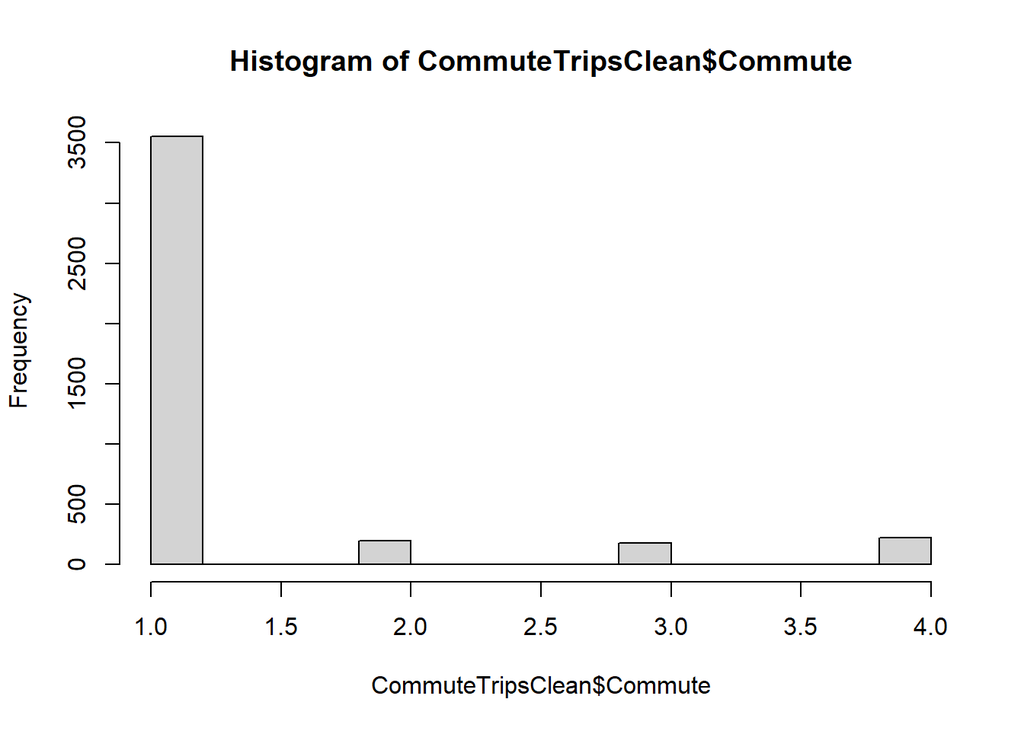

```r
#plot frequency of each mode chosen
hist(CommuteTripsClean$Commute)
```

Clean Data More

```r
#let's merge in on person number and SAMPN
#we have to merge together the SAMPN and the person number
#there is already a column called X that represents SAMPN + PERNO but this is how you would create it
CommuteTripsClean$SAMPN_PER <- do.call(paste, c(CommuteTripsClean[c("SAMPN", "PERNO")], sep = ""))

head(CommuteTripsClean)
```

```
## # A tibble: 6 × 83
##     SAMPN PERNO     ...3 PLANO ATIME DTIME TRPDUR ACTDUR Origin_PTYPE Dest_PTYE
##     <dbl> <dbl>    <dbl> <dbl> <dbl> <dbl>  <dbl>  <dbl>        <dbl>     <dbl>
## 1 1000018     1 10000181     2   800   830     90     30            1         2
## 2 1000018     1 10000181     4  1040  1135     40     55            5         2
## 3 1000024     2 10000242     2   645  1630     25    585            1         2
## 4 1000054     1 10000541     2   805  1455      5    410            1         2
## 5 1000212     2 10002122     2   900  1732     60    512            1         2
## 6 1000239     1 10002391     2   815  1206     37    231            1         2
## # ℹ 73 more variables: PLOC <dbl>, ...12 <lgl>, ACT1 <dbl>,
## #   `Work/NotWork` <dbl>, Origin <dbl>, Mode <dbl>, TT <dbl>, ACT2 <dbl>,
## #   ACT3 <dbl>, ACT4 <dbl>, ACT5 <dbl>, ACT6 <dbl>, ACT1O <lgl>, ACTO <lgl>,
## #   TRAN1 <dbl>, TRAN2 <dbl>, TRAN3 <dbl>, TRAN4 <lgl>, OTRAN <lgl>,
## #   HHVU <dbl>, HHVNO <dbl>, ADP <dbl>, TOTTRAV <dbl>, NTRAV <dbl>,
## #   NHTRV <dbl>, PHHTR <chr>, NNHTR <dbl>, PARK <dbl>, PARKO <lgl>,
## #   PARKC <dbl>, PARKU <dbl>, PRKUO <lgl>, TOLL <dbl>, TOLLA <dbl>, …
```

```r
##but still, some people take multiple work trips. Let's just grab the first work trip
CommuteTripsClean <- subset(CommuteTripsClean, !duplicated(SAMPN_PER))
head(CommuteTripsClean, 20)
```

```
## # A tibble: 20 × 83
##      SAMPN PERNO     ...3 PLANO ATIME DTIME TRPDUR ACTDUR Origin_PTYPE Dest_PTYE
##      <dbl> <dbl>    <dbl> <dbl> <dbl> <dbl>  <dbl>  <dbl>        <dbl>     <dbl>
##  1 1000018     1 10000181     2   800   830     90     30            1         2
##  2 1000024     2 10000242     2   645  1630     25    585            1         2
##  3 1000054     1 10000541     2   805  1455      5    410            1         2
##  4 1000212     2 10002122     2   900  1732     60    512            1         2
##  5 1000239     1 10002391     2   815  1206     37    231            1         2
##  6 1000244     1 10002441     2   818  1615      3    477            1         2
##  7 1000244     2 10002442     2   745  1500     30    435            1         2
##  8 1000253     1 10002531     2   840  1130     15    170            1         2
##  9 1000253     2 10002532     2   900  1700     10    480            1         2
## 10 1000271     1 10002711     2   815  1735     40    560            1         2
## 11 1000271     2 10002712     2   815  1730     40    555            1         2
## 12 1000317     1 10003171     2   955  1730     25    455            1         2
## 13 1000317     2 10003172     4  1300  1800     15    300            1         2
## 14 1000341     1 10003411     3   830  1630     15    480            5         2
## 15 1000341     2 10003412     2   900  1030     30     90            1         2
## 16 1000465     1 10004651     2   925  1600     40    395            1         2
## 17 1000465     2 10004652     2   910  1300     10    230            1         2
## 18 1000468     4 10004684     2  1040  1600     10    320            1         2
## 19 1000711     1 10007111     2   810  1700     36    530            1         2
## 20 1000714     1 10007141     2   822  1200     12    218            1         2
## # ℹ 73 more variables: PLOC <dbl>, ...12 <lgl>, ACT1 <dbl>,
## #   `Work/NotWork` <dbl>, Origin <dbl>, Mode <dbl>, TT <dbl>, ACT2 <dbl>,
## #   ACT3 <dbl>, ACT4 <dbl>, ACT5 <dbl>, ACT6 <dbl>, ACT1O <lgl>, ACTO <lgl>,
## #   TRAN1 <dbl>, TRAN2 <dbl>, TRAN3 <dbl>, TRAN4 <lgl>, OTRAN <lgl>,
## #   HHVU <dbl>, HHVNO <dbl>, ADP <dbl>, TOTTRAV <dbl>, NTRAV <dbl>,
## #   NHTRV <dbl>, PHHTR <chr>, NNHTR <dbl>, PARK <dbl>, PARKO <lgl>,
## #   PARKC <dbl>, PARKU <dbl>, PRKUO <lgl>, TOLL <dbl>, TOLLA <dbl>, …
```

```r
#let's merge in on person number and SAMPN
per_hh_dat <- merge(per_dat, hh_dat,
                    by.x = "SAMPN",
                    by.y = "SAMPN",
                    all.x = TRUE,
                    all.y=FALSE,
                    sort = FALSE)

#get rid of columns we don't need
colnamCleaning<-c("VETMO", "W2TY", "W2TYO",  "W2TYP", "W2LOC", "W2IND", "W2INO", "W2OCC", "W2OCO", "W2DAY", "W2HOM", "W2HOO", "W2ST", "W2ET",  "W1WKD3", "W1WKD4", "W1WKE", "W1WKD1", "W1WKD2")
per_datClean<-per_hh_dat[ , -which(names(per_dat) %in% colnamCleaning)]
head(per_datClean)
```

```
##     SAMPN PERNO GEND AGE LIC RESP RELAT DISAB DISTY1 DISTY2 DABLO EDUC LEVEL
## 1 1000024     1    1  50   1    1     1     2     NA     NA  <NA>    2    NA
## 2 1000024     2    2  45   1    2     2     2     NA     NA  <NA>    2    NA
## 3 1000054     1    2  60   1    1     1     2     NA     NA  <NA>    2    NA
## 4 1000054     2    1  64   1    2     2     2     NA     NA  <NA>    2    NA
## 5 1000175     1    2  65   1    1     1     2     NA     NA  <NA>    2    NA
## 6 1000175     2    1  37   1    2     3     2     NA     NA  <NA>    2    NA
##   S_LOC SHOME SDAY SMODE1 SMODE2 SMODE3 SMOO SCOST SUNIT EMPL NOJOB NMJOB ETYPE
## 1    NA    NA   NA     NA     NA     NA   NA    NA    NA    1    NA     2     3
## 2    NA    NA   NA     NA     NA     NA   NA    NA    NA    1    NA     2     1
## 3    NA    NA   NA     NA     NA     NA   NA    NA    NA    1    NA     2     2
## 4    NA    NA   NA     NA     NA     NA   NA    NA    NA    3     1    NA    NA
## 5    NA    NA   NA     NA     NA     NA   NA    NA    NA    2    NA     2     1
## 6    NA    NA   NA     NA     NA     NA   NA    NA    NA    3     3    NA    NA
##   ETYPO W1IND W1INO W1OCC W1OCO W1TIM W1DAY W1HOM W1HMO W1CPR W1CPT W1CPO
```

[output cut: 55 more lines]

```r
## we have to merge together the SAMPN and the person number
per_datClean$SAMPN_PER <- do.call(paste, c(per_datClean[c("SAMPN", "PERNO")], sep = ""))
head(per_datClean)
```

```
##     SAMPN PERNO GEND AGE LIC RESP RELAT DISAB DISTY1 DISTY2 DABLO EDUC LEVEL
## 1 1000024     1    1  50   1    1     1     2     NA     NA  <NA>    2    NA
## 2 1000024     2    2  45   1    2     2     2     NA     NA  <NA>    2    NA
## 3 1000054     1    2  60   1    1     1     2     NA     NA  <NA>    2    NA
## 4 1000054     2    1  64   1    2     2     2     NA     NA  <NA>    2    NA
## 5 1000175     1    2  65   1    1     1     2     NA     NA  <NA>    2    NA
## 6 1000175     2    1  37   1    2     3     2     NA     NA  <NA>    2    NA
##   S_LOC SHOME SDAY SMODE1 SMODE2 SMODE3 SMOO SCOST SUNIT EMPL NOJOB NMJOB ETYPE
## 1    NA    NA   NA     NA     NA     NA   NA    NA    NA    1    NA     2     3
## 2    NA    NA   NA     NA     NA     NA   NA    NA    NA    1    NA     2     1
## 3    NA    NA   NA     NA     NA     NA   NA    NA    NA    1    NA     2     2
## 4    NA    NA   NA     NA     NA     NA   NA    NA    NA    3     1    NA    NA
## 5    NA    NA   NA     NA     NA     NA   NA    NA    NA    2    NA     2     1
## 6    NA    NA   NA     NA     NA     NA   NA    NA    NA    3     3    NA    NA
##   ETYPO W1IND W1INO W1OCC W1OCO W1TIM W1DAY W1HOM W1HMO W1CPR W1CPT W1CPO
```

[output cut: 55 more lines]

```r
#merge trip with person and household
CommuteTripsPerson <- merge(CommuteTripsClean, per_datClean,
                            by.x = "SAMPN_PER",
                            by.y = "SAMPN_PER",
                            all.x = TRUE,
                            all.y=FALSE,
                            sort = FALSE)
dim(CommuteTripsPerson)
```

```
## [1] 3476  195
```

```r
head(CommuteTripsPerson)
```

```
##   SAMPN_PER SAMPN.x PERNO.x     ...3 PLANO ATIME DTIME TRPDUR ACTDUR
## 1  10000181 1000018       1 10000181     2   800   830     90     30
## 2  10000242 1000024       2 10000242     2   645  1630     25    585
## 3  10000541 1000054       1 10000541     2   805  1455      5    410
## 4  10002122 1000212       2 10002122     2   900  1732     60    512
## 5  10002391 1000239       1 10002391     2   815  1206     37    231
## 6  10002441 1000244       1 10002441     2   818  1615      3    477
##   Origin_PTYPE Dest_PTYE PLOC ...12 ACT1 Work/NotWork  Origin Mode TT ACT2 ACT3
## 1            1         2   26    NA   11            1 9000018   21  0   NA   NA
## 2            1         2  173    NA   11            1 9000024   21  0   NA   NA
## 3            1         2   60    NA   11            1 9000054   21  0   NA   NA
## 4            1         2  167    NA   11            1 9000212   21  0   NA   NA
## 5            1         2  186    NA   11            1 9000239   21  0    3   NA
## 6            1         2  187    NA   11            1 9000244   21  0   NA   NA
##   ACT4 ACT5 ACT6 ACT1O ACTO TRAN1 TRAN2 TRAN3 TRAN4 OTRAN HHVU HHVNO ADP
```

[output cut: 104 more lines]

```r
##let's check there is no one with 2 yes:
CommuteTripsPerson$check<-CommuteTripsPerson$transit+CommuteTripsPerson$drivealone+CommuteTripsPerson$bike+CommuteTripsPerson$carpool
max(CommuteTripsPerson$check)
```

```
## [1] 1
```

```r
##finally, we can think about modeling
#keep only useful variables
varsInterest <- c("SAMPN", "PERNO", "AGE", "GENDER", "INCOME", "SAMPN_PER", "TOLLA", "TOLL", "PARKC", "PARKU", "PRKUO", "TRPDUR", "drivealone", "bike", "transit", "carpool", "Commute")
CommuteTripsPerson<-CommuteTripsPerson[ , which(names(CommuteTripsPerson) %in% varsInterest)]
head(CommuteTripsPerson)
```

```
##   SAMPN_PER TRPDUR PARKC PARKU PRKUO TOLL TOLLA bike drivealone transit carpool
## 1  10000181     90     0    NA    NA    2    NA    0          1       0       0
## 2  10000242     25     0    NA    NA    2    NA    0          1       0       0
## 3  10000541      5     0    NA    NA    2    NA    0          1       0       0
## 4  10002122     60     0    NA    NA    2    NA    0          1       0       0
## 5  10002391     37     0    NA    NA    2    NA    0          1       0       0
## 6  10002441      3     0    NA    NA    2    NA    0          1       0       0
##   Commute AGE INCOME
## 1       1  60     NA
## 2       1  45 175000
## 3       1  60  62000
## 4       1  45 137000
## 5       1  34  30000
## 6       1  38 137000
```

```r
#getting rid of NAs in income
CommuteTripsPerson<-CommuteTripsPerson[-which(is.na(CommuteTripsPerson$INCOME)),]
head(CommuteTripsPerson)
```

```
##   SAMPN_PER TRPDUR PARKC PARKU PRKUO TOLL TOLLA bike drivealone transit carpool
## 2  10000242     25     0    NA    NA    2    NA    0          1       0       0
## 3  10000541      5     0    NA    NA    2    NA    0          1       0       0
## 4  10002122     60     0    NA    NA    2    NA    0          1       0       0
## 5  10002391     37     0    NA    NA    2    NA    0          1       0       0
## 6  10002441      3     0    NA    NA    2    NA    0          1       0       0
## 7  10002442     30     0    NA    NA    2    NA    0          1       0       0
##   Commute AGE INCOME
## 2       1  45 175000
## 3       1  60  62000
## 4       1  45 137000
## 5       1  34  30000
## 6       1  38 137000
## 7       1  38 137000
```

Split Data to calculate trip duration and then rejoin data.

```r
#let's do the time calculation for each mode separately
#here I'm splitting the data set into three based on mode choice
Biking<-CommuteTripsPerson[which(CommuteTripsPerson$bike ==1),]
Drivealone<-CommuteTripsPerson[which(CommuteTripsPerson$drivealone ==1),]
Transit<-CommuteTripsPerson[which(CommuteTripsPerson$transit ==1),]
Carpool<-CommuteTripsPerson[which(CommuteTripsPerson$carpool ==1),]

#double check and see if each data set indeed only has information for one mode
table(Biking$Commute)
```

```
##
##   4
## 123
```

```r
table(Drivealone$Commute)
```

```
##
##    1
## 2622
```

```r
table(Transit$Commute)
```

```
##
##   3
## 152
```

```r
table(Carpool$Commute)
```

```
##
##   2
## 141
```

```r
#distance = speed * time in minutes
Drivealone$distance<-(35/60)*Drivealone$TRPDUR
Biking$distance<-(12/60)*Biking$TRPDUR
Transit$distance<-(25/60)*Transit$TRPDUR
Carpool$distance<-(30/60)*Carpool$TRPDUR

#re-combine the three data sets
dat<-rbind(Biking, Transit, Drivealone, Carpool)
head(dat)
```

```
##     SAMPN_PER TRPDUR PARKC PARKU PRKUO TOLL TOLLA bike drivealone transit
## 35   10014112     29    NA    NA    NA   NA    NA    1          0       0
## 162  10068022      2    NA    NA    NA   NA    NA    1          0       0
## 221  10076163     15    NA    NA    NA   NA    NA    1          0       0
## 253  10081512      2    NA    NA    NA   NA    NA    1          0       0
## 256  10081791      3    NA    NA    NA   NA    NA    1          0       0
## 263  10091492     30    NA    NA    NA   NA    NA    1          0       0
##     carpool Commute AGE INCOME distance
## 35        0       4  34  62000      5.8
## 162       0       4  53 112000      0.4
## 221       0       4  19  62000      3.0
## 253       0       4  21  30000      0.4
## 256       0       4  53  42000      0.6
## 263       0       4  60  87000      6.0
```

```r
#now we can calc a trip duration on every mode
#in other words, this is what the trip duration WOULD be if the person had chosen each mode
dat$time.auto <-dat$distance/35
dat$time.bike <- dat$distance/12
dat$time.transit <- dat$distance/25
dat$time.carpool <- dat$distance/30

head(dat)
```

```
##     SAMPN_PER TRPDUR PARKC PARKU PRKUO TOLL TOLLA bike drivealone transit
## 35   10014112     29    NA    NA    NA   NA    NA    1          0       0
## 162  10068022      2    NA    NA    NA   NA    NA    1          0       0
## 221  10076163     15    NA    NA    NA   NA    NA    1          0       0
## 253  10081512      2    NA    NA    NA   NA    NA    1          0       0
## 256  10081791      3    NA    NA    NA   NA    NA    1          0       0
## 263  10091492     30    NA    NA    NA   NA    NA    1          0       0
##     carpool Commute AGE INCOME distance  time.auto  time.bike time.transit
## 35        0       4  34  62000      5.8 0.16571429 0.48333333        0.232
## 162       0       4  53 112000      0.4 0.01142857 0.03333333        0.016
## 221       0       4  19  62000      3.0 0.08571429 0.25000000        0.120
## 253       0       4  21  30000      0.4 0.01142857 0.03333333        0.016
## 256       0       4  53  42000      0.6 0.01714286 0.05000000        0.024
## 263       0       4  60  87000      6.0 0.17142857 0.50000000        0.240
##     time.carpool
## 35    0.19333333
## 162   0.01333333
## 221   0.10000000
## 253   0.01333333
## 256   0.02000000
## 263   0.20000000
```

```r
#add a variable to enable us to recast the data later on
dat$mode[dat$bike == 1] <- "bike"
dat$mode[dat$transit == 1] <- "transit"
dat$mode[dat$drivealone == 1] <- "auto"
dat$mode[dat$carpool == 1] <- "carpool"
head(dat)
```

```
##     SAMPN_PER TRPDUR PARKC PARKU PRKUO TOLL TOLLA bike drivealone transit
## 35   10014112     29    NA    NA    NA   NA    NA    1          0       0
## 162  10068022      2    NA    NA    NA   NA    NA    1          0       0
## 221  10076163     15    NA    NA    NA   NA    NA    1          0       0
## 253  10081512      2    NA    NA    NA   NA    NA    1          0       0
## 256  10081791      3    NA    NA    NA   NA    NA    1          0       0
## 263  10091492     30    NA    NA    NA   NA    NA    1          0       0
##     carpool Commute AGE INCOME distance  time.auto  time.bike time.transit
## 35        0       4  34  62000      5.8 0.16571429 0.48333333        0.232
## 162       0       4  53 112000      0.4 0.01142857 0.03333333        0.016
## 221       0       4  19  62000      3.0 0.08571429 0.25000000        0.120
## 253       0       4  21  30000      0.4 0.01142857 0.03333333        0.016
## 256       0       4  53  42000      0.6 0.01714286 0.05000000        0.024
## 263       0       4  60  87000      6.0 0.17142857 0.50000000        0.240
##     time.carpool mode
## 35    0.19333333 bike
## 162   0.01333333 bike
## 221   0.10000000 bike
## 253   0.01333333 bike
## 256   0.02000000 bike
## 263   0.20000000 bike
```

```r
#the row indices are messed up because of the subsets we did
#need to fix them
rownames(dat) <- NULL
head(dat)
```

```
##   SAMPN_PER TRPDUR PARKC PARKU PRKUO TOLL TOLLA bike drivealone transit carpool
## 1  10014112     29    NA    NA    NA   NA    NA    1          0       0       0
## 2  10068022      2    NA    NA    NA   NA    NA    1          0       0       0
## 3  10076163     15    NA    NA    NA   NA    NA    1          0       0       0
## 4  10081512      2    NA    NA    NA   NA    NA    1          0       0       0
## 5  10081791      3    NA    NA    NA   NA    NA    1          0       0       0
## 6  10091492     30    NA    NA    NA   NA    NA    1          0       0       0
##   Commute AGE INCOME distance  time.auto  time.bike time.transit time.carpool
## 1       4  34  62000      5.8 0.16571429 0.48333333        0.232   0.19333333
## 2       4  53 112000      0.4 0.01142857 0.03333333        0.016   0.01333333
## 3       4  19  62000      3.0 0.08571429 0.25000000        0.120   0.10000000
## 4       4  21  30000      0.4 0.01142857 0.03333333        0.016   0.01333333
## 5       4  53  42000      0.6 0.01714286 0.05000000        0.024   0.02000000
## 6       4  60  87000      6.0 0.17142857 0.50000000        0.240   0.20000000
##   mode
## 1 bike
## 2 bike
## 3 bike
## 4 bike
## 5 bike
## 6 bike
```

```r
varsInterest <- c("AGE", "GENDER", "INCOME", "time.auto", "time.bike", "time.transit", "time.carpool", "mode")
dat<-dat[ , which(names(dat) %in% varsInterest)]
head(dat)
```

```
##   AGE INCOME  time.auto  time.bike time.transit time.carpool mode
## 1  34  62000 0.16571429 0.48333333        0.232   0.19333333 bike
## 2  53 112000 0.01142857 0.03333333        0.016   0.01333333 bike
## 3  19  62000 0.08571429 0.25000000        0.120   0.10000000 bike
## 4  21  30000 0.01142857 0.03333333        0.016   0.01333333 bike
## 5  53  42000 0.01714286 0.05000000        0.024   0.02000000 bike
## 6  60  87000 0.17142857 0.50000000        0.240   0.20000000 bike
```

```r
require(mlogit)

#let's try...
head(dat)
```

```
##   AGE INCOME  time.auto  time.bike time.transit time.carpool mode
## 1  34  62000 0.16571429 0.48333333        0.232   0.19333333 bike
## 2  53 112000 0.01142857 0.03333333        0.016   0.01333333 bike
## 3  19  62000 0.08571429 0.25000000        0.120   0.10000000 bike
## 4  21  30000 0.01142857 0.03333333        0.016   0.01333333 bike
## 5  53  42000 0.01714286 0.05000000        0.024   0.02000000 bike
## 6  60  87000 0.17142857 0.50000000        0.240   0.20000000 bike
```

```r
datMNL <- mlogit.data(dat, shape="wide", choice="mode", varying=c(3:6))

#check it!
head(datMNL, 20)
```

```
## ~~~~~~~
##  first 20 observations out of 12152
## ~~~~~~~
##    AGE INCOME  mode     alt       time chid    idx
## 1   34  62000 FALSE    auto 0.16571429    1 1:auto
## 2   34  62000  TRUE    bike 0.48333333    1 1:bike
## 3   34  62000 FALSE carpool 0.19333333    1 1:pool
## 4   34  62000 FALSE transit 0.23200000    1 1:nsit
## 5   53 112000 FALSE    auto 0.01142857    2 2:auto
## 6   53 112000  TRUE    bike 0.03333333    2 2:bike
## 7   53 112000 FALSE carpool 0.01333333    2 2:pool
## 8   53 112000 FALSE transit 0.01600000    2 2:nsit
## 9   19  62000 FALSE    auto 0.08571429    3 3:auto
## 10  19  62000  TRUE    bike 0.25000000    3 3:bike
## 11  19  62000 FALSE carpool 0.10000000    3 3:pool
```

[output cut: 33 more lines]

## Build Models

```r
#let's first look at a few different model specifications
#formula specification
#(dependent variable ~ alternative specific | decision maker specific)
#intercept only
mod.int <- mlogit (mode ~ 1, data = datMNL)
summary(mod.int)
```

```
##
## Call:
## mlogit(formula = mode ~ 1, data = datMNL, method = "nr")
##
## Frequencies of alternatives:choice
##     auto     bike  carpool  transit
## 0.863068 0.040487 0.046412 0.050033
##
## nr method
## 5 iterations, 0h:0m:0s
## g'(-H)^-1g = 0.000793
## successive function values within tolerance limits
##
## Coefficients :
##                      Estimate Std. Error z-value  Pr(>|z|)
## (Intercept):bike    -3.059508   0.092258 -33.163 < 2.2e-16 ***
## (Intercept):carpool -2.922932   0.086450 -33.811 < 2.2e-16 ***
## (Intercept):transit -2.847810   0.083429 -34.135 < 2.2e-16 ***
## ---
## Signif. codes:  0 '***' 0.001 '**' 0.01 '*' 0.05 '.' 0.1 ' ' 1
##
## Log-Likelihood: -1668.7
## McFadden R^2:  -2.2204e-16
## Likelihood ratio test : chisq = -4.5475e-13 (p.value = 1)
```

```r
#the coefficients are associated with probability/proportion of each mode

#only alt. specific
mod <- mlogit (mode ~ time | 1, data = datMNL)
summary(mod)
```

```
##
## Call:
## mlogit(formula = mode ~ time | 1, data = datMNL, method = "nr")
##
## Frequencies of alternatives:choice
##     auto     bike  carpool  transit
## 0.863068 0.040487 0.046412 0.050033
##
## nr method
## 7 iterations, 0h:0m:0s
## g'(-H)^-1g = 0.000115
## successive function values within tolerance limits
##
## Coefficients :
##                      Estimate Std. Error  z-value  Pr(>|z|)
## (Intercept):bike    -1.016914   0.156772  -6.4866 8.782e-11 ***
## (Intercept):carpool -2.635905   0.090149 -29.2395 < 2.2e-16 ***
## (Intercept):transit -2.216914   0.098399 -22.5298 < 2.2e-16 ***
## time                -4.178355   0.384291 -10.8729 < 2.2e-16 ***
## ---
## Signif. codes:  0 '***' 0.001 '**' 0.01 '*' 0.05 '.' 0.1 ' ' 1
##
## Log-Likelihood: -1566.6
## McFadden R^2:  0.061162
## Likelihood ratio test : chisq = 204.12 (p.value = < 2.22e-16)
```

```r
#only decision maker (individual) specific
mod1 <- mlogit (mode ~ 1 | AGE + INCOME, data = datMNL)
summary(mod1)
```

```
##
## Call:
## mlogit(formula = mode ~ 1 | AGE + INCOME, data = datMNL, method = "nr")
##
## Frequencies of alternatives:choice
##     auto     bike  carpool  transit
## 0.863068 0.040487 0.046412 0.050033
##
## nr method
## 5 iterations, 0h:0m:0s
## g'(-H)^-1g = 4.44E-07
## gradient close to zero
##
## Coefficients :
##                        Estimate  Std. Error  z-value  Pr(>|z|)
## (Intercept):bike    -2.8235e+00  2.1206e-01 -13.3147 < 2.2e-16 ***
## (Intercept):carpool -2.4282e+00  1.9606e-01 -12.3848 < 2.2e-16 ***
## (Intercept):transit -1.7326e+00  1.8816e-01  -9.2080 < 2.2e-16 ***
## AGE:bike            -2.3622e-04  1.2588e-03  -0.1877  0.851146
## AGE:carpool          1.6564e-04  1.0148e-03   0.1632  0.870346
## AGE:transit          4.8298e-04  8.9738e-04   0.5382  0.590428
## INCOME:bike         -2.9871e-06  2.5013e-06  -1.1942  0.232397
## INCOME:carpool      -6.9447e-06  2.4850e-06  -2.7946  0.005196 **
## INCOME:transit      -1.7150e-05  2.7907e-06  -6.1455 7.973e-10 ***
## ---
## Signif. codes:  0 '***' 0.001 '**' 0.01 '*' 0.05 '.' 0.1 ' ' 1
##
## Log-Likelihood: -1642.5
## McFadden R^2:  0.015681
## Likelihood ratio test : chisq = 52.335 (p.value = 1.597e-09)
```

```r
#both alternative and individual specific
mod1 <- mlogit (mode ~ time | INCOME, data = datMNL)
summary(mod1)
```

```
##
## Call:
## mlogit(formula = mode ~ time | INCOME, data = datMNL, method = "nr")
##
## Frequencies of alternatives:choice
##     auto     bike  carpool  transit
## 0.863068 0.040487 0.046412 0.050033
##
## nr method
## 7 iterations, 0h:0m:0s
## g'(-H)^-1g = 0.000112
## successive function values within tolerance limits
##
## Coefficients :
##                        Estimate  Std. Error  z-value  Pr(>|z|)
## (Intercept):bike    -8.8691e-01  2.4397e-01  -3.6353 0.0002776 ***
## (Intercept):carpool -2.1548e+00  1.9260e-01 -11.1877 < 2.2e-16 ***
## (Intercept):transit -1.1197e+00  1.9132e-01  -5.8528 4.835e-09 ***
## time                -4.1301e+00  3.8333e-01 -10.7740 < 2.2e-16 ***
## INCOME:bike         -1.9362e-06  2.5338e-06  -0.7642 0.4447698
## INCOME:carpool      -6.6969e-06  2.4908e-06  -2.6886 0.0071745 **
## INCOME:transit      -1.6683e-05  2.8173e-06  -5.9215 3.189e-09 ***
## ---
## Signif. codes:  0 '***' 0.001 '**' 0.01 '*' 0.05 '.' 0.1 ' ' 1
##
## Log-Likelihood: -1542.8
## McFadden R^2:  0.075449
## Likelihood ratio test : chisq = 251.8 (p.value = < 2.22e-16)
```

## Model Testing

```r
#goodness of fit
#McFadden's R squared measures how the current model
#compares with the intercept only model
#what's the McFadden's R squared for the intercept only model?
summary(mod.int)
```

```
##
## Call:
## mlogit(formula = mode ~ 1, data = datMNL, method = "nr")
##
## Frequencies of alternatives:choice
##     auto     bike  carpool  transit
## 0.863068 0.040487 0.046412 0.050033
##
## nr method
## 5 iterations, 0h:0m:0s
## g'(-H)^-1g = 0.000793
## successive function values within tolerance limits
##
## Coefficients :
##                      Estimate Std. Error z-value  Pr(>|z|)
## (Intercept):bike    -3.059508   0.092258 -33.163 < 2.2e-16 ***
## (Intercept):carpool -2.922932   0.086450 -33.811 < 2.2e-16 ***
## (Intercept):transit -2.847810   0.083429 -34.135 < 2.2e-16 ***
## ---
## Signif. codes:  0 '***' 0.001 '**' 0.01 '*' 0.05 '.' 0.1 ' ' 1
##
## Log-Likelihood: -1668.7
## McFadden R^2:  -2.2204e-16
## Likelihood ratio test : chisq = -4.5475e-13 (p.value = 1)
```

```r
#likelihood ratio test (chisq test)- tests decrease in unexpained variance
#from baseline model to final model (models must be nested!!!)
#deviance = -2 * log likelihood
#remember deviance?

#think back to chisq test we did for binomial
modelChi <- (-2*(-1104.5)) - (-2*(-1007))

#this is the chisq in output
summary(mod)
```

```
##
## Call:
## mlogit(formula = mode ~ time | 1, data = datMNL, method = "nr")
##
## Frequencies of alternatives:choice
##     auto     bike  carpool  transit
## 0.863068 0.040487 0.046412 0.050033
##
## nr method
## 7 iterations, 0h:0m:0s
## g'(-H)^-1g = 0.000115
## successive function values within tolerance limits
##
## Coefficients :
##                      Estimate Std. Error  z-value  Pr(>|z|)
## (Intercept):bike    -1.016914   0.156772  -6.4866 8.782e-11 ***
## (Intercept):carpool -2.635905   0.090149 -29.2395 < 2.2e-16 ***
## (Intercept):transit -2.216914   0.098399 -22.5298 < 2.2e-16 ***
## time                -4.178355   0.384291 -10.8729 < 2.2e-16 ***
## ---
## Signif. codes:  0 '***' 0.001 '**' 0.01 '*' 0.05 '.' 0.1 ' ' 1
##
## Log-Likelihood: -1566.6
## McFadden R^2:  0.061162
## Likelihood ratio test : chisq = 204.12 (p.value = < 2.22e-16)
```

```r
#calculating change in degree of freedom
mod$logLik
```

```
## 'log Lik.' -1566.642 (df=4)
```

```r
df.mod <- 3
mod.int$logLik
```

```
## 'log Lik.' -1668.703 (df=3)
```

```r
df.mod.int <- 2

chidf <- df.mod - df.mod.int

#if prob < 0.05, then the final model significantly improves fit
chisq.prob <- 1 - pchisq(modelChi, chidf)
chisq.prob #this is the chisq p-value in the output
```

```
## [1] 0
```

```r
summary(mod)
```

```
##
## Call:
## mlogit(formula = mode ~ time | 1, data = datMNL, method = "nr")
##
## Frequencies of alternatives:choice
##     auto     bike  carpool  transit
## 0.863068 0.040487 0.046412 0.050033
##
## nr method
## 7 iterations, 0h:0m:0s
## g'(-H)^-1g = 0.000115
## successive function values within tolerance limits
##
## Coefficients :
##                      Estimate Std. Error  z-value  Pr(>|z|)
## (Intercept):bike    -1.016914   0.156772  -6.4866 8.782e-11 ***
## (Intercept):carpool -2.635905   0.090149 -29.2395 < 2.2e-16 ***
## (Intercept):transit -2.216914   0.098399 -22.5298 < 2.2e-16 ***
## time                -4.178355   0.384291 -10.8729 < 2.2e-16 ***
## ---
## Signif. codes:  0 '***' 0.001 '**' 0.01 '*' 0.05 '.' 0.1 ' ' 1
##
## Log-Likelihood: -1566.6
## McFadden R^2:  0.061162
## Likelihood ratio test : chisq = 204.12 (p.value = < 2.22e-16)
```

```r
#Akaike Info Criterion
AIC(mod.int, mod, mod1)
```

```
##         df      AIC
## mod.int  3 3343.405
## mod      4 3141.283
## mod1     7 3099.601
```

```r
#interpretation for coefficients
summary(mod1)
```

```
##
## Call:
## mlogit(formula = mode ~ time | INCOME, data = datMNL, method = "nr")
##
## Frequencies of alternatives:choice
##     auto     bike  carpool  transit
## 0.863068 0.040487 0.046412 0.050033
##
## nr method
## 7 iterations, 0h:0m:0s
## g'(-H)^-1g = 0.000112
## successive function values within tolerance limits
##
## Coefficients :
##                        Estimate  Std. Error  z-value  Pr(>|z|)
## (Intercept):bike    -8.8691e-01  2.4397e-01  -3.6353 0.0002776 ***
## (Intercept):carpool -2.1548e+00  1.9260e-01 -11.1877 < 2.2e-16 ***
## (Intercept):transit -1.1197e+00  1.9132e-01  -5.8528 4.835e-09 ***
## time                -4.1301e+00  3.8333e-01 -10.7740 < 2.2e-16 ***
## INCOME:bike         -1.9362e-06  2.5338e-06  -0.7642 0.4447698
## INCOME:carpool      -6.6969e-06  2.4908e-06  -2.6886 0.0071745 **
## INCOME:transit      -1.6683e-05  2.8173e-06  -5.9215 3.189e-09 ***
## ---
## Signif. codes:  0 '***' 0.001 '**' 0.01 '*' 0.05 '.' 0.1 ' ' 1
##
## Log-Likelihood: -1542.8
## McFadden R^2:  0.075449
## Likelihood ratio test : chisq = 251.8 (p.value = < 2.22e-16)
```

```r
library(stargazer)
stargazer(mod.int, mod, mod1, type = "text")
```

```
##
## ===========================================================================
##                                       Dependent variable:
##                     -------------------------------------------------------
##                                              mode
##                           (1)               (2)                 (3)
## ---------------------------------------------------------------------------
## (Intercept):bike       -3.060***         -1.017***           -0.887***
##                         (0.092)           (0.157)             (0.244)
##
## (Intercept):carpool    -2.923***         -2.636***           -2.155***
##                         (0.086)           (0.090)             (0.193)
##
## (Intercept):transit    -2.848***         -2.217***           -1.120***
##                         (0.083)           (0.098)             (0.191)
##
## time                                     -4.178***           -4.130***
##                                           (0.384)             (0.383)
##
## INCOME:bike                                                  -0.00000
##                                                              (0.00000)
##
## INCOME:carpool                                              -0.00001***
##                                                              (0.00000)
##
## INCOME:transit                                              -0.00002***
##                                                              (0.00000)
##
## ---------------------------------------------------------------------------
## Observations             3,038             3,038               3,038
## R2                      -0.000             0.061               0.075
## Log Likelihood        -1,668.703        -1,566.642          -1,542.800
## LR Test             -0.000 (df = 3) 204.122*** (df = 4) 251.804*** (df = 7)
## ===========================================================================
## Note:                                           *p<0.1; **p<0.05; ***p<0.01
```

From this, it looks like mod1 is our best model since it has the lowest AIC. But what do the results of our model mean?

Visualize the probabilities of each choice

```r
# Create a data frame with a range of time and income values to predict probabilities
new_data <- expand.grid(
  time = seq(min(datMNL$time), max(datMNL$time), length.out = 100),
  INCOME = c(min(datMNL$INCOME), median(datMNL$INCOME), max(datMNL$INCOME))
)

# Calculate the predicted probabilities for each transportation choice
predicted_probs <- as.data.frame(predict(mod1, newdata = new_data, type = "prob"))

# Join the predicted probabilities to the new_data data frame
new_data <- cbind(new_data, predicted_probs)
```

This plot shows our model’s prediction of the impact of time on mode choice for different income levels

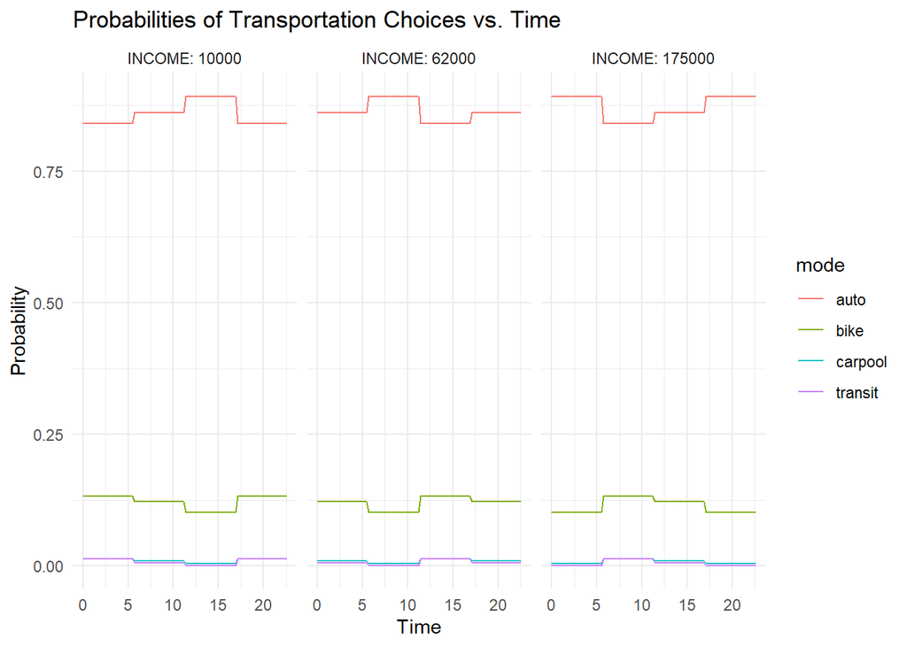

```r
new_data_long <- new_data %>%
  gather(key = "mode", value = "probability", -time, -INCOME)

ggplot(new_data_long, aes(x = time, y = probability, color = mode)) +
  geom_line() +
  facet_wrap(~ INCOME, labeller = label_both) +
  labs(x = "Time", y = "Probability", title = "Probabilities of Transportation Choices vs. Time") +
  theme_minimal()
```

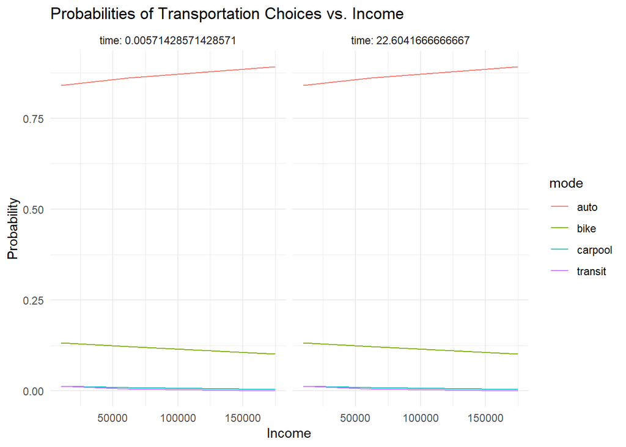

```r
# Subset the data for a few specific time values
time_subset <- c(min(datMNL$time), median(datMNL$time), max(datMNL$time))
new_data_income_subset <- new_data_long %>% filter(time %in% time_subset)

# Create the plot
ggplot(new_data_income_subset, aes(x = INCOME, y = probability, color = mode)) +
  geom_line() +
  facet_wrap(~ time, labeller = label_both) +
  labs(x = "Income", y = "Probability", title = "Probabilities of Transportation Choices vs. Income") +
  theme_minimal()
```

(Intercept):bike, (Intercept):carpool, and (Intercept):transit: These coefficients represent the baseline log-odds of choosing each alternative mode over auto, keeping the other predictors constant. All three intercepts are negative and statistically significant, indicating that the odds of choosing bike, carpool, or transit are lower than auto when time and income are held constant.

This model has relatively low fit, suggested by its McFadden R^2 of 0.075449. Human behavior is shaped by a large number of factors, not all of which can be captured in a survey such as the one used to generate this dataset. Some additional factors to gather data on would be environmental factors such as distance to public transit and population density and personal factors such as an individual’s perceived safety of modes.

The chi-square value is 251.8, with a p-value < 2.22e-16, suggesting that the model’s predictors (time and income) significantly improve the model’s fit compared to an intercept-only model. The model’s base category is “auto,” and it has the highest frequency (0.863068). This indicates that the model would perform best in predicting the “auto” mode choice, as it’s the most common choice in the dataset. For the opposite reasons, this model performs worst for biking, which is the least common choice in the dataset.